# ggutils: a toolbox for ggplot2

# Local annotations and heatmap labels (anno_mark style)

The `"diagonal"` geometry matches `circlize` and `ComplexHeatmap::anno_mark()` exactly: short stub, diagonal, short stub, text. Together with the track strategy (“one row when it fits, clustered labels split into tracks”) this is ideal for **labelling only a few categories of interest**.

## Labels that sit in one stretch of the axis: automatic tracks

If the labels selected by `which` only occupy a small stretch of the axis, the guide splits them over several rows with vertical staggering, and every label still connects to its own tick:

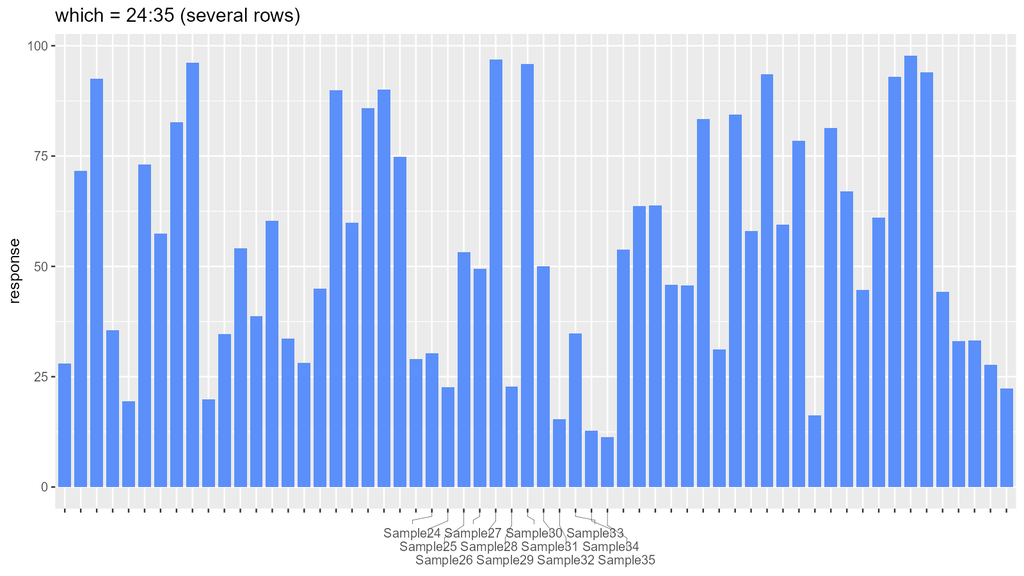

only labels 24-35 of 60 categories: split over several rows automatically

```r
set.seed(5)
labs60 <- paste0("Sample", 1:60)
df60 <- data.frame(
  sample = factor(labs60, levels = labs60),
  value = round(runif(60, 10, 100), 1)
)

ggplot(df60, aes(x = sample, y = value)) +
  geom_col(fill = "#5B8FF9", width = 0.8) +
  guides(x = guide_axis_smart(which = 24:35)) +
  labs(x = NULL, y = "response", title = "which = 24:35 (several rows)") +
  theme_grey(base_size = 12)
```

To force the single-row, pure `anno_mark` look (labels stretched along the axis, longer leader lines), write `nrow = 1`:

```
#> ! The requested nrow = 1 is probably too small for 12 labels: some of them will
#>   not be drawn.
#> ℹ Increase `nrow`, or select fewer labels with `which` / `n`.
```

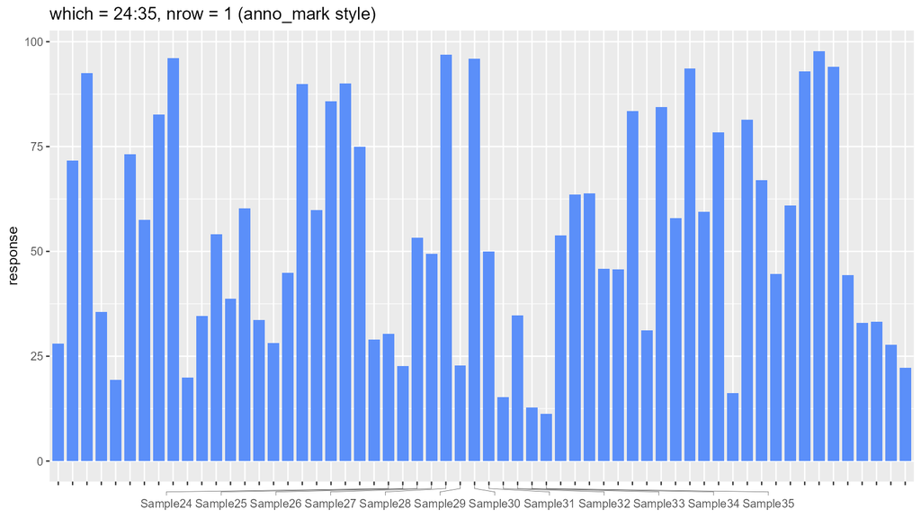

the same labels with nrow = 1: stretched along the axis, longer leader lines

```r
ggplot(df60, aes(x = sample, y = value)) +
  geom_col(fill = "#5B8FF9", width = 0.8) +
  guides(x = guide_axis_smart(which = 24:35, nrow = 1)) +
  labs(x = NULL, y = "response", title = "which = 24:35, nrow = 1 (anno_mark style)") +
  theme_grey(base_size = 12)
```

## Heatmap labels: `sec.axis` + `dup_axis()`

“Label only a few rows and hide the rest” is the typical `anno_mark()` use case. Switch the main axis off, duplicate it with `dup_axis()`, and attach the smart guide to the copy.

This section uses the data set bundled with the package, **`airway_heatmap`**: real RNA-seq from GEO (GSE52778; human airway smooth muscle cells, four cell lines with and without dexamethasone). The data is already processed — expressed genes only, `log2(CPM + 1)`, the 300 most variable genes; heatmap examples below use per-sample z-scores (each sample standardised across the genes), ordered by hierarchical clustering (see `?airway_heatmap` for the exact steps) — so the chunks below load it and plot immediately.

To make the leader lines and the vertical distribution of the labels visible, the heatmap shows **300 genes** and labels 20 of them (12 neighbouring genes from the top response cluster plus 8 scattered genes):

```r
## bundled data: 300 genes x 8 samples, per-sample z-scores for the heat maps
data(airway_heatmap, package = "ggutils")
df_gene <- airway_sample_z
mark    <- airway_heatmap$mark
```

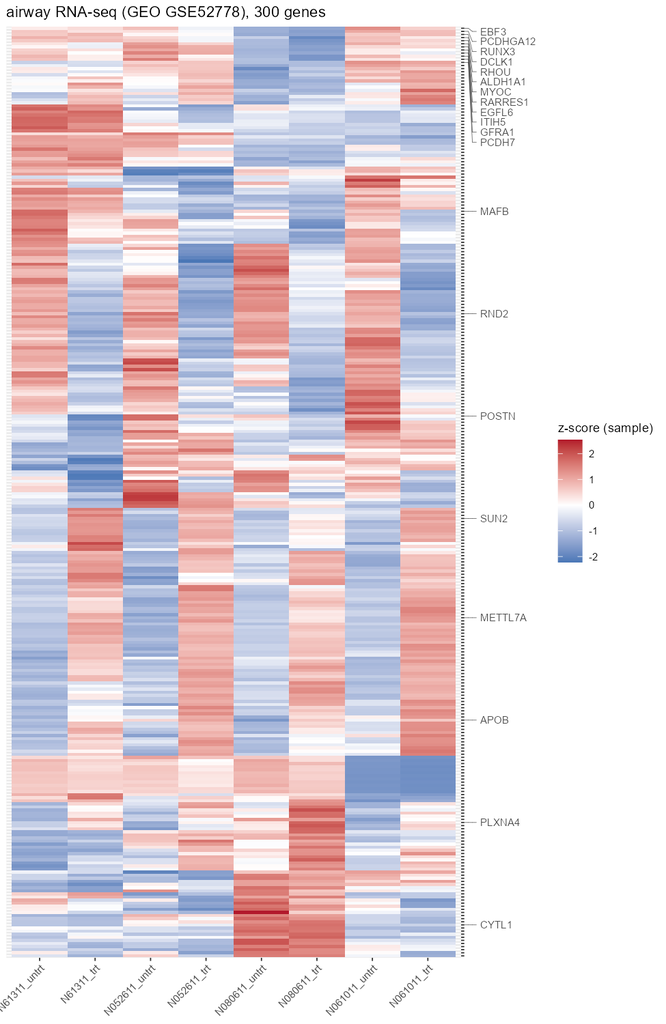

real data (GEO GSE52778), a tall 300-gene heatmap: only 20 genes are labelled, showing how the leader lines and the vertical label spacing are allocated

```r
ggplot(df_gene, aes(x = sample, y = gene, fill = z_sample)) +
  geom_tile() +
  scale_y_discrete(
    guide = guide_none(),
    sec.axis = dup_axis(
      guide = guide_axis_smart(which = mark)
    )
  ) +
  scale_fill_gradient2(low = "#2166ac", mid = "white", high = "#b2182b",
                       midpoint = 0, name = "z-score (sample)") +
  labs(x = NULL, y = NULL, title = "airway RNA-seq (GEO GSE52778), 300 genes") +
  theme_grey(base_size = 9) +
  theme(axis.text.x = element_text(angle = 45, hjust = 1))
```

When the heatmap is faceted, every panel holds different data and lays out its own labels. Here the genes are split into an “up” and a “down” panel, and each panel labels only its four strongest responders (panel heights follow the number of genes):

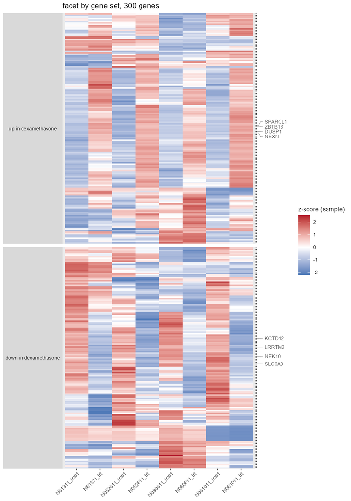

faceted heatmap: each panel has different data and lays out its own labels

```r
## the four strongest responders of each gene set are precomputed in the data
mark_facet <- unlist(airway_heatmap$mark_by_set, use.names = FALSE)

ggplot(df_gene, aes(x = sample, y = gene, fill = z_sample)) +
  geom_tile() +
  facet_grid(gene_set ~ ., scales = "free_y", space = "free_y", switch = "y") +
  scale_y_discrete(
    position = "right",
    guide = guide_axis_smart(
      which = function(labels, positions) labels %in% mark_facet
    )
  ) +
  scale_fill_gradient2(low = "#2166ac", mid = "white", high = "#b2182b",
                       midpoint = 0, name = "z-score (sample)") +
  labs(x = NULL, y = NULL, title = "facet by gene set, 300 genes") +
  theme_grey(base_size = 9) +
  theme(panel.grid = element_blank(),
        strip.placement = "outside",
        strip.text.y.left = element_text(angle = 0),
        axis.text.x = element_text(angle = 45, hjust = 1))
```

Key points:

- single panel: hide all labels on the main axis with `guide = guide_none()` and put `guide_axis_smart()` on the axis created by `dup_axis()`;
- with hundreds of rows the effect is easiest to see: labels that crowd into the same strip are staggered vertically and each leader line goes back to its own row, while isolated labels get a longer horizontal line;
- **facets**: each panel selects and lays out its own labels independently; use a function for `which` (`function(labels, positions)`) so that every panel only matches the labels that exist in it;
- `dup_axis()` is not drawn per panel in a faceted plot; attach the smart guide directly with `scale_y_discrete(position = "right", guide = ...)` instead;
- `airway_heatmap` ships with the package (`data/airway_heatmap.rda`), so no `airway` or `SummarizedExperiment` dependency is needed at render time; the processing steps are documented in `?airway_heatmap` if you want to rebuild it from the original counts.

# Long labels and angles: `angle`, `hjust`, `vjust`

When the label text is long (for example “Sample12 (Treated A)”), staggering over rows may still not be enough; rotate the labels instead. `angle` accepts `0`, `45` and `90`; `NULL` (the default) inherits the angle from `axis.text.x` in the theme.

```
#> ! The requested nrow = 2 is probably too small for 12 labels: some of them will
#>   not be drawn.
#> ℹ Increase `nrow`, or select fewer labels with `which` / `n`.
```

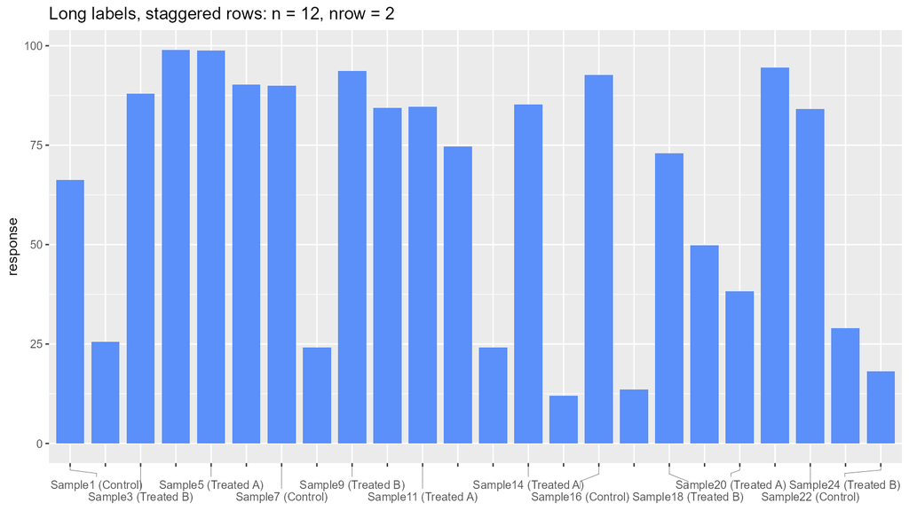

long labels with staggered rows (no rotation): n = 12, nrow = 2

```r
trt <- rep(c("Control", "Treated A", "Treated B"), 8)
labs24 <- paste0("Sample", 1:24, " (", trt, ")")
df24 <- data.frame(
  sample = factor(labs24, levels = labs24),
  value = round(runif(24, 10, 100), 1)
)

ggplot(df24, aes(x = sample, y = value)) +
  geom_col(fill = "#5B8FF9", width = 0.8) +
  guides(x = guide_axis_smart(n = 12, nrow = 2)) +
  labs(x = NULL, y = "response", title = "Long labels, staggered rows: n = 12, nrow = 2") +
  theme_grey(base_size = 12)
```

```
#> ! The requested nrow = 1 is probably too small for 12 labels: some of them will
#>   not be drawn.
#> ℹ Increase `nrow`, or select fewer labels with `which` / `n`.
```

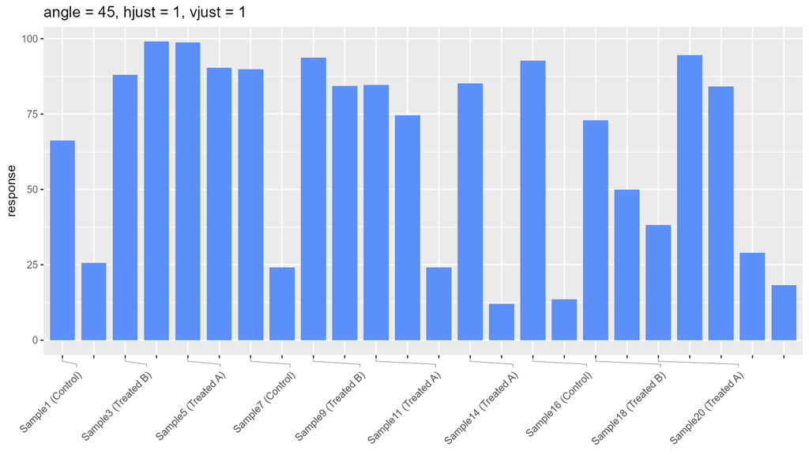

angle = 45 with nrow = 1, hjust = 1 and vjust = 1

```r
ggplot(df24, aes(x = sample, y = value)) +
  geom_col(fill = "#5B8FF9", width = 0.8) +
  guides(x = guide_axis_smart(n = 12, nrow = 1, angle = 45, hjust = 1, vjust = 1)) +
  labs(x = NULL, y = "response", title = "angle = 45, hjust = 1, vjust = 1") +
  theme_grey(base_size = 12)
```

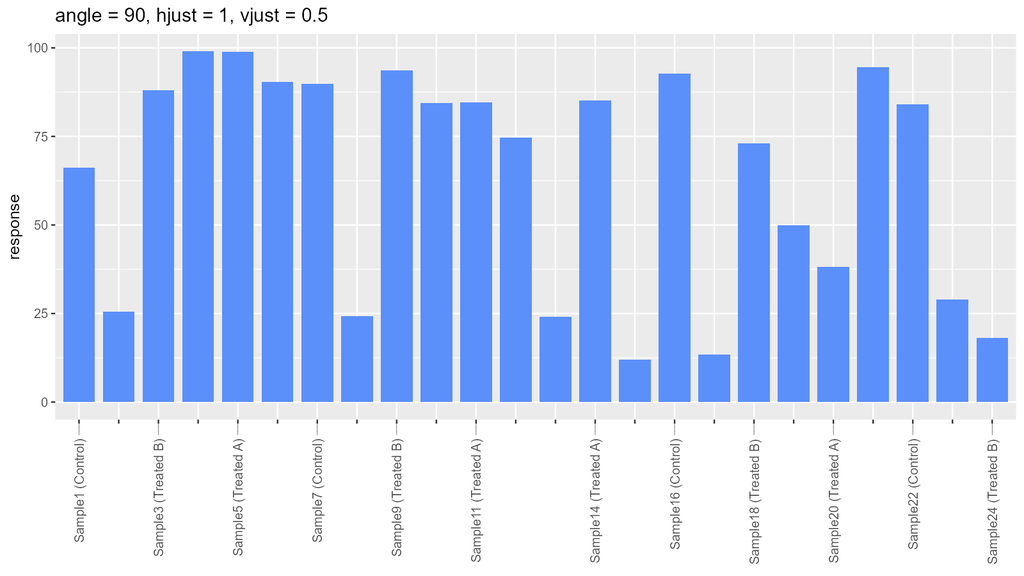

angle = 90 with hjust = 1 and vjust = 0.5

```r
ggplot(df24, aes(x = sample, y = value)) +
  geom_col(fill = "#5B8FF9", width = 0.8) +
  guides(x = guide_axis_smart(n = 12, nrow = 1, angle = 90, hjust = 1, vjust = 0.5)) +
  labs(x = NULL, y = "response", title = "angle = 90, hjust = 1, vjust = 0.5") +
  theme_grey(base_size = 12)
```

`hjust` / `vjust` are passed to the label text grob; with `NULL` the guide picks a sensible value for the angle. In practice:

- `angle = 0`: leave the defaults;
- `angle = 45`: `hjust = 1, vjust = 1` (right-aligned, next to the tick);
- `angle = 90`: `hjust = 1, vjust = 0.5`.

# Continuous axes work too

`guide_axis_smart()` does not require a discrete axis. With `scale_*_continuous(breaks = ...)` you can request many ticks and then show only a subset, over one or several rows:

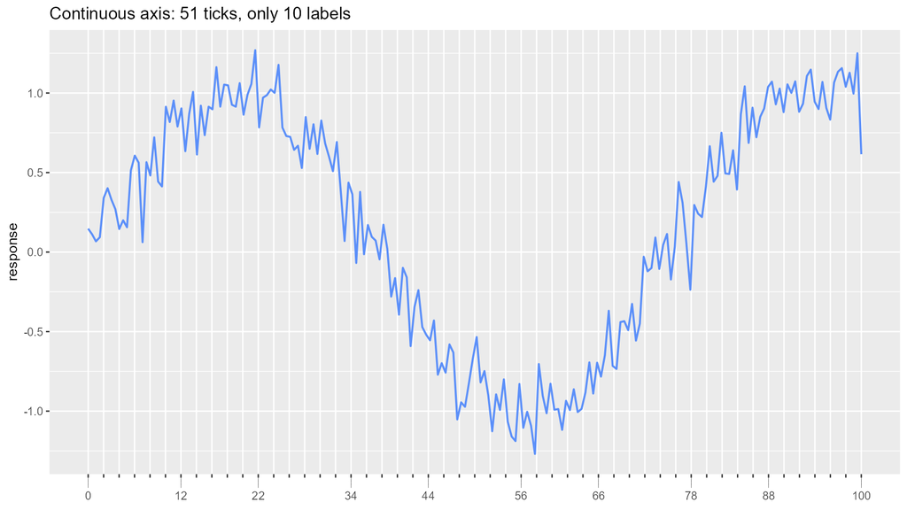

continuous axis: 51 tick labels, only 10 displayed

```r
set.seed(2024)
df_curve <- data.frame(
  x = seq(0, 100, length.out = 200),
  y = sin(seq(0, 100, length.out = 200) / 12) + rnorm(200, sd = 0.15)
)

ggplot(df_curve, aes(x, y)) +
  geom_line(colour = "#5B8FF9", linewidth = 0.8) +
  scale_x_continuous(breaks = seq(0, 100, by = 2), minor_breaks = NULL) +
  guides(x = guide_axis_smart(n = 10)) +
  labs(x = NULL, y = "response", title = "Continuous axis: 51 ticks, only 10 labels") +
  theme_grey(base_size = 12)
```

On a continuous axis the character form of `which` matches the **formatted** tick text (e.g. `"20"`); for position-based rules the function form is more robust.

# Working with facets, coord_flip and themes

## facet: each panel lays out its own labels

Facetting gives every panel its own axis; the guide does its layout independently in each panel (a narrower panel may need more rows), and each panel only picks labels from its own breaks.

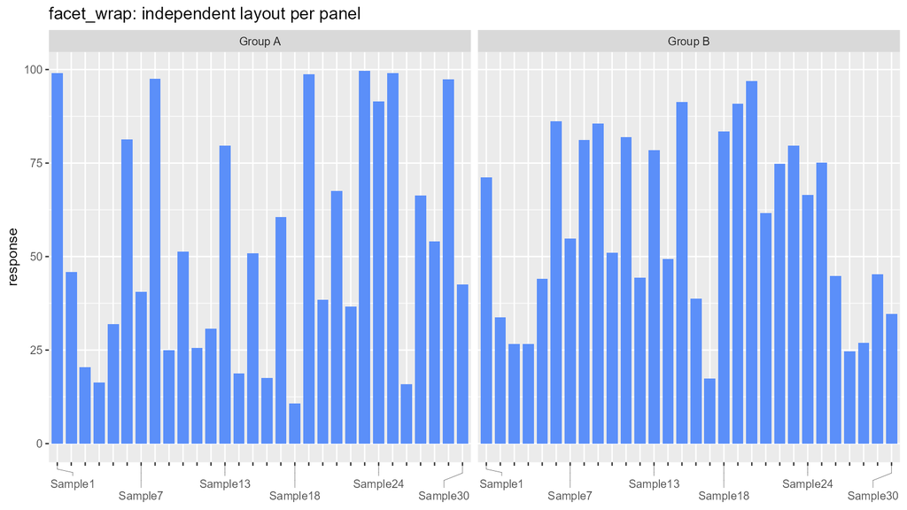

facet_wrap: each panel lays out its labels independently

```r
set.seed(7)
df_facet <- data.frame(
  sample = factor(paste0("Sample", 1:30), levels = paste0("Sample", 1:30)),
  value = round(runif(60, 10, 100), 1),
  group = rep(c("Group A", "Group B"), each = 30)
)

ggplot(df_facet, aes(x = sample, y = value)) +
  geom_col(fill = "#5B8FF9", width = 0.8) +
  facet_wrap(~ group, scales = "free_x") +
  guides(x = guide_axis_smart(n = 6, nrow = 2)) +
  labs(x = NULL, y = "response", title = "facet_wrap: independent layout per panel") +
  theme_grey(base_size = 12)
```

### Free scales: each panel labels only what it contains

With `scales = "free_x"` (or `free_y`) every panel carries different categories. Write all the labels you want to mark once in `which`; each panel only draws the ones it actually has, and labels that are **not present in a panel are skipped silently** (no error, no warning per panel):

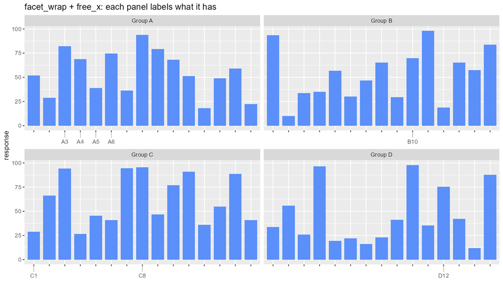

facet_wrap + free_x: each panel labels only its own categories

```r
set.seed(8)
df_facet_free <- data.frame(
  cat = factor(
    c(paste0("A", 1:15), paste0("B", 1:15), paste0("C", 1:15), paste0("D", 1:15)),
    levels = c(paste0("A", 1:15), paste0("B", 1:15), paste0("C", 1:15), paste0("D", 1:15))
  ),
  value = round(runif(60, 10, 100), 1),
  group = rep(c("Group A", "Group B", "Group C", "Group D"), each = 15)
)
mark_facet_free <- c("A3", "A4", "A5", "A6", "B10", "C1", "C8", "D12")

ggplot(df_facet_free, aes(cat, value)) +
  geom_col(fill = "#5B8FF9", width = 0.8) +
  facet_wrap(~ group, nrow = 2, scales = "free_x") +
  guides(x = guide_axis_smart(which = mark_facet_free)) +
  labs(x = NULL, y = "response",
       title = "facet_wrap + free_x: each panel labels what it has") +
  theme_grey(base_size = 11)
```

### Crowded labels inside one panel

A run of neighbouring labels is spread over several rows *inside that panel*; the narrower the panel, the more rows are used. Here `nrow = 3` is forced:

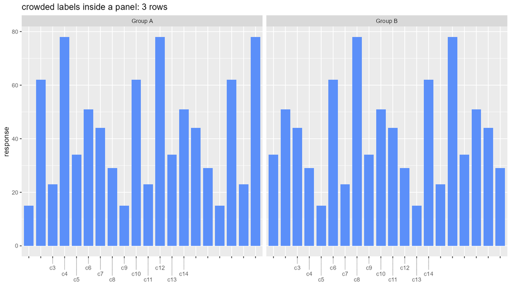

12 crowded labels inside a panel: spread over 3 rows

```r
df_facet_crowd <- data.frame(
  cat = factor(paste0("c", 1:20), levels = paste0("c", 1:20)),
  value = rep(c(15, 62, 23, 78, 34, 51, 44, 29), length.out = 40),
  group = rep(c("Group A", "Group B"), each = 20)
)

ggplot(df_facet_crowd, aes(cat, value)) +
  geom_col(fill = "#5B8FF9", width = 0.8) +
  facet_wrap(~ group, nrow = 1) +
  guides(x = guide_axis_smart(which = 3:14, nrow = 3)) +
  labs(x = NULL, y = "response",
       title = "crowded labels inside a panel: 3 rows") +
  theme_grey(base_size = 11)
```

### facet_grid: a shared axis is drawn once, free axes once per panel

With `facet_grid` and a shared x axis the guide is drawn once; with `scales = "free_x"` every column gets its own:

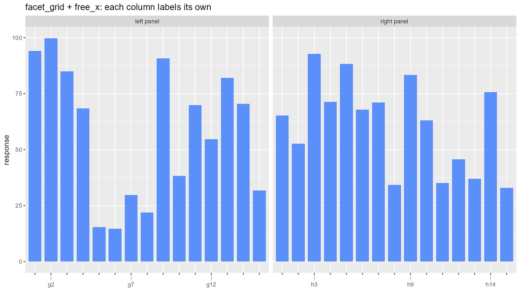

facet_grid + free_x: each column labels its own categories

```r
df_facet_grid <- data.frame(
  cat = factor(c(paste0("g", 1:15), paste0("h", 1:15)),
               levels = c(paste0("g", 1:15), paste0("h", 1:15))),
  value = round(runif(30, 10, 100), 1),
  side = rep(c("left panel", "right panel"), each = 15)
)

ggplot(df_facet_grid, aes(cat, value)) +
  geom_col(fill = "#5B8FF9", width = 0.8) +
  facet_grid(. ~ side, scales = "free_x") +
  guides(x = guide_axis_smart(which = c("g2", "g7", "g12", "h3", "h9", "h14"))) +
  labs(x = NULL, y = "response",
       title = "facet_grid + free_x: each column labels its own") +
  theme_grey(base_size = 11)
```

### Faceted heatmap: the right-hand y axis is labelled per panel

For a faceted heatmap attach the guide with `scale_y_discrete(position = "right")`; with `free_y` each panel labels only the genes it contains, and a crowded run of genes is spread over rows inside that panel:

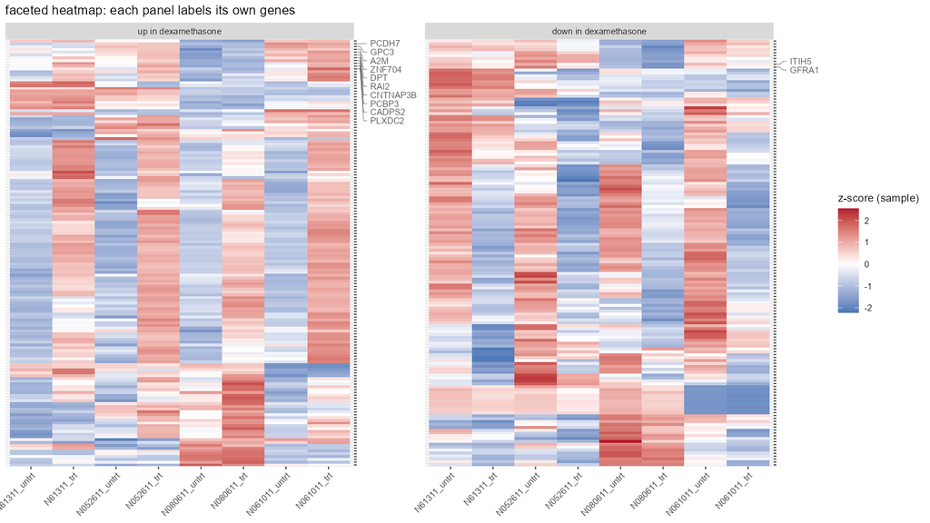

faceted heatmap: the bundled real data, each panel labels its own genes

```r
## the real RNA-seq data bundled with the package (GEO GSE52778, 300 genes x 8 samples)
data(airway_heatmap, package = "ggutils")
df_facet_heat <- airway_sample_z
mark_wrap <- airway_heatmap$genes$gene[10:21]   # 12 neighbouring genes of the top cluster

ggplot(df_facet_heat, aes(sample, gene, fill = z_sample)) +
  geom_tile() +
  facet_wrap(~ gene_set, nrow = 1, scales = "free_y") +
  scale_y_discrete(
    position = "right",
    guide = guide_axis_smart(which = mark_wrap)
  ) +
  scale_fill_gradient2(low = "#2166ac", mid = "white", high = "#b2182b",
                       midpoint = 0, name = "z-score (sample)") +
  labs(x = NULL, y = NULL,
       title = "faceted heatmap: each panel labels its own genes") +
  theme_grey(base_size = 9) +
  theme(axis.text.x = element_text(angle = 45, hjust = 1))
```

### Facet checklist

- both `facet_wrap` and `facet_grid` work; the guide lays out inside every panel;
- `free_x` / `free_y`: each panel draws only the labels it has, so a single `which` can cover all panels;
- shared scales: the axis is drawn once (`facet_grid` rows share x, columns share y);
- crowding: a narrower panel uses more rows automatically, or force it with `nrow`;
- facets + `dup_axis()` do not work (the copy is not drawn per panel); attach the guide with `scale_*_discrete(position =, guide =)` instead.

## coord_flip: supported, but mapping to the y axis is recommended

`coord_flip()` has been superseded since ggplot2 4.0; map the discrete variable to the y axis instead (see above).

If old code still uses `coord_flip()`, **attach the guide to the scale**: in the flipped coordinate system `guides(x = ...)` looks up the guide by position, so it ends up on the numeric axis at the bottom instead of the discrete axis on the left. This spelling works:

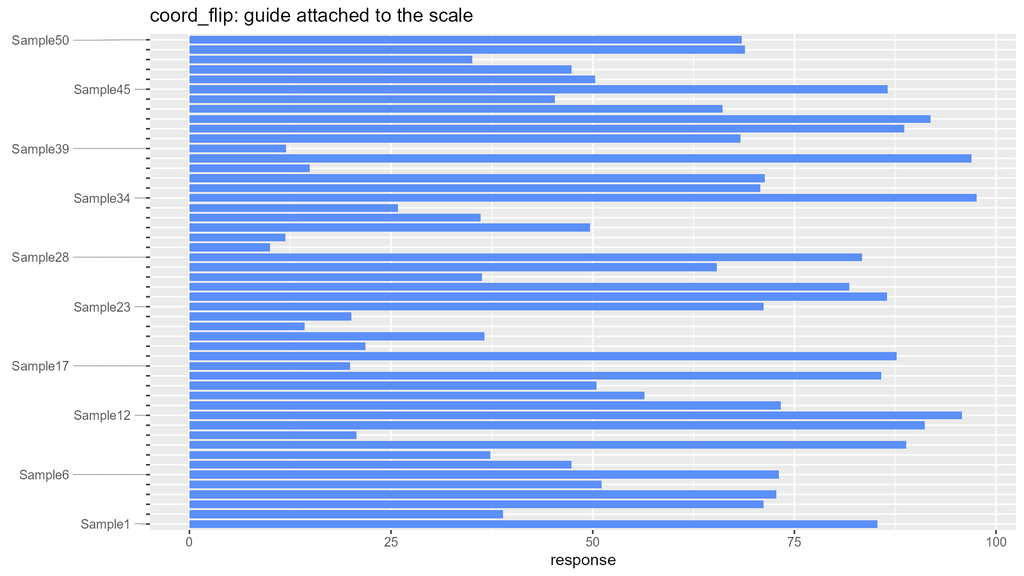

after coord_flip(): the x labels become a vertical axis, the guide is attached to the scale

```r
ggplot(df50, aes(x = sample, y = value)) +
  geom_col(fill = "#5B8FF9", width = 0.8) +
  scale_x_discrete(guide = guide_axis_smart(n = 10, nrow = 2)) +
  coord_flip() +
  labs(x = NULL, y = "response", title = "coord_flip: guide attached to the scale") +
  theme_grey(base_size = 12)
```

The equivalent spelling is `guides(y = guide_axis_smart(...))` — after flipping, the discrete axis’s guide slot moves to `y`.

## theme: text styles are inherited

Colour, size, font family and face of the labels are inherited from `axis.text.x` / `axis.text.y`, so `theme()` code keeps working:

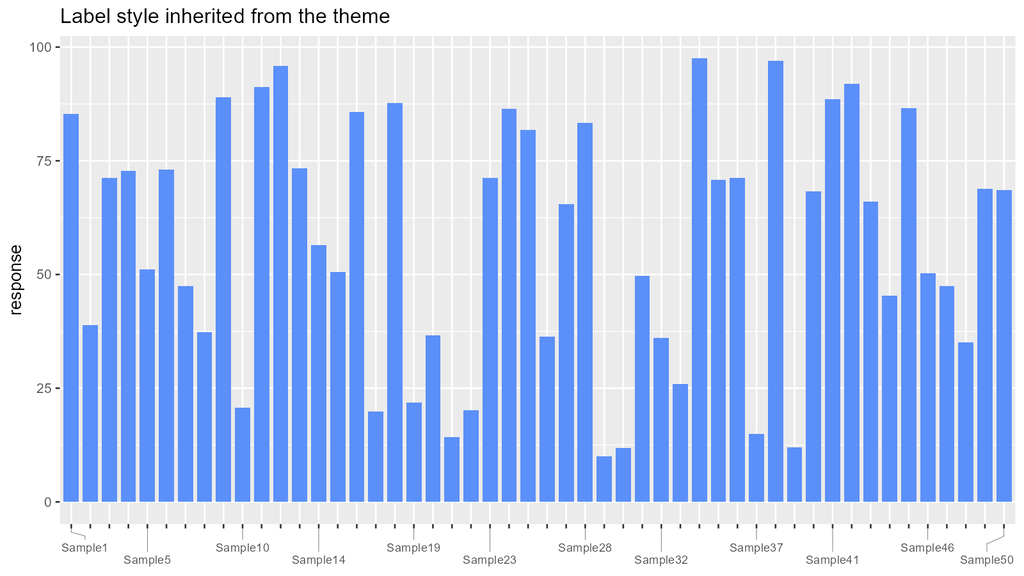

label style inherited from axis.text.x: grey, 9 pt

```r
ggplot(df50, aes(x = sample, y = value)) +
  geom_col(fill = "#5B8FF9", width = 0.8) +
  guides(x = guide_axis_smart(n = 12, nrow = 2)) +
  labs(x = NULL, y = "response", title = "Label style inherited from the theme") +
  theme_grey(base_size = 13) +
  theme(axis.text.x = element_text(colour = "grey30", size = 9))
```

Do **not** use `theme(axis.text.x = element_blank())` — the guide inherits that blank element verbatim and all labels disappear.

# `facet_gridn()`: a per-panel `facet_grid`

`facet_grid(scales = "free_x")` frees x **per column**: panels stacked in the same column still share one x axis, because the layout sets `SCALE_X` to the column index. `facet_gridn()` lays the panels out exactly the same way (rows and columns, row strips on the right, column strips on top) but sets `SCALE_X` / `SCALE_Y` to the **panel** index, so every cell trains its own scale, gets its own range and its own axis.

| `scales` | freedom | x axis | y axis |
| --- | --- | --- | --- |
| `"fixed"` | shared (default) | one global axis | one global axis |
| `"free_x"` | **per panel** | one axis per panel | one global axis |
| `"free_y"` | **per panel** | one global axis | one axis per panel |
| `"free"` | **per panel** | one axis per panel | one axis per panel |
| `"free_x_bycol"` | same as `facet_grid()` | one axis per column | one global axis |
| `"free_y_byrow"` | same as `facet_grid()` | one global axis | one axis per row |

The last two are compatibility values: `free_x_bycol` / `free_y_byrow` are exactly the stock `free_x` / `free_y`, which is what you want when one figure has to mix both kinds of freedom (x shared per column, y independent per panel). `scales = "fixed"` matches `facet_grid()` pixel for pixel and can be swapped in at any time.

All examples below use `mpg` (`drv`: 3 rows x `year`: 2 columns = 6 panels):

```r
library(patchwork)
```

```r
d_cont <- mpg
d_disc <- mpg
d_disc$cylgrp <- factor(ifelse(d_disc$cyl == 4, "4 cyl", "6 / 8 cyl"),
                        levels = c("4 cyl", "6 / 8 cyl"))
th_n <- theme_bw(base_size = 9) +
  theme(panel.grid.minor = element_blank(),
        strip.text = element_text(size = 8),
        axis.text = element_text(size = 7),
        plot.title = element_text(size = 9))
p_cont_n <- function(scales, fn = facet_gridn) {
  ggplot(d_cont, aes(displ, hwy)) +
    geom_point(size = 1.2, alpha = 0.8) +
    fn(vars(drv), vars(year), scales = scales) +
    labs(title = scales, x = NULL, y = NULL) + th_n
}
```

## Continuous axes: the four modes side by side

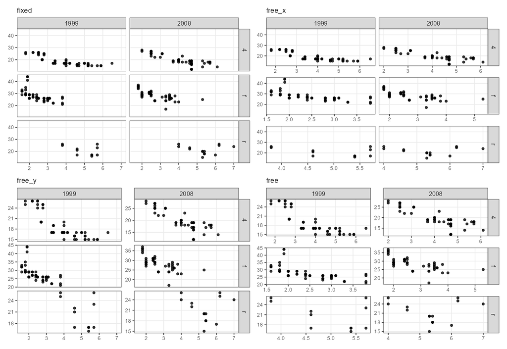

continuous axes, four scales: fixed shares everything, free_x / free_y free one direction per panel, free frees both

```r
(p_cont_n("fixed")  | p_cont_n("free_x")) /
  (p_cont_n("free_y") | p_cont_n("free"))
```

With `free_x` every panel carries its own tick labels underneath, with `free_y` every panel has its own ticks on the left, and `free` has both. The difference is measurable: on the same data the stock `facet_grid(scales = "free_x")` produces only **2** distinct x ranges (one per column), `facet_gridn()` produces **6** (one per panel); `free_y` is the mirror image – 3 for stock (one per row), 6 for `facet_gridn()`.

## Categorical x: every panel keeps only its own categories

In `mpg`, `2seater` only occurs in the `r` row and `minivan` only in the `f` row, which makes “each panel keeps only its own categories” easy to see:

```r
p_catx_n <- function(fn = facet_gridn) {
  ggplot(d_cont, aes(class, hwy)) +
    geom_boxplot(fill = "grey92", linewidth = 0.3, outlier.size = 0.8) +
    fn(vars(drv), vars(year), scales = "free_x") +
    th_n + theme(axis.text.x = element_text(angle = 45, hjust = 1))
}
```

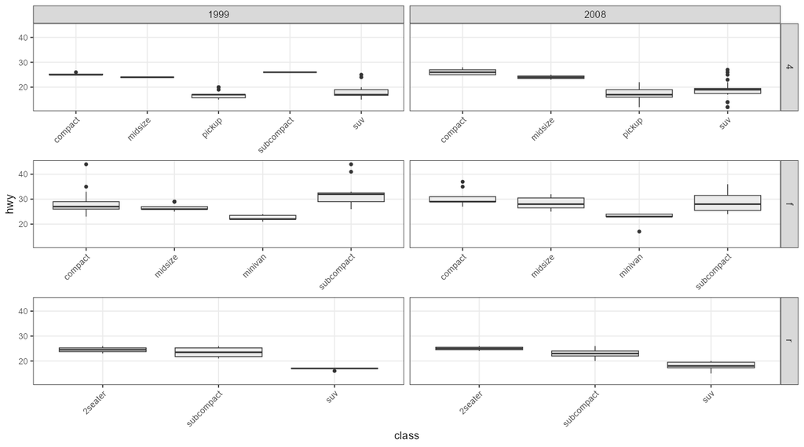

facet_gridn(scales = ‘free_x’): each panel’s x axis lists only the categories it contains

```r
p_catx_n()
```

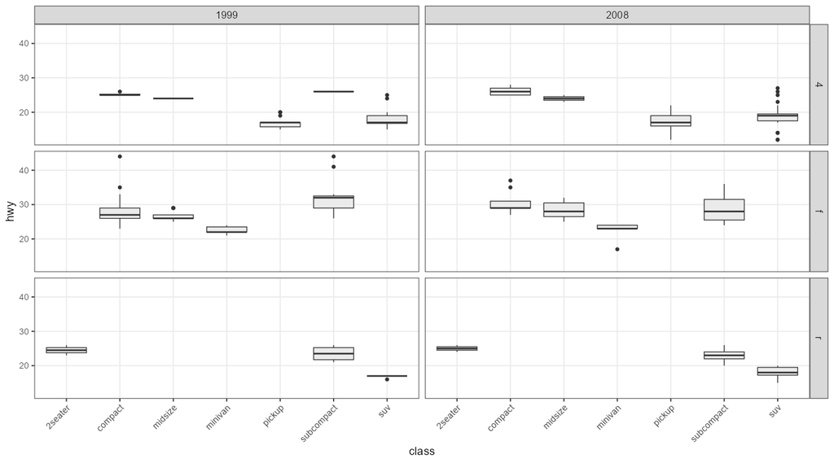

the same data with facet_grid(scales = ‘free_x’): the x axis only sits under the bottom row, and a column shares its union

```r
p_catx_n(facet_grid)
```

## Categorical y: the same rule, other direction

```r
p_caty_n <- function(fn = facet_gridn) {
  ggplot(d_cont, aes(hwy, class)) +
    geom_boxplot(fill = "grey92", linewidth = 0.3, outlier.size = 0.8) +
    fn(vars(year), vars(drv), scales = "free_y") +
    th_n
}
```

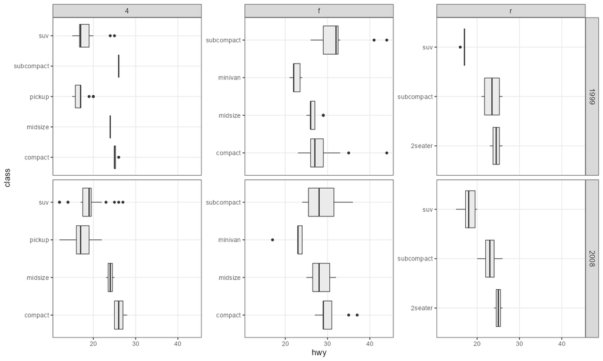

facet_gridn(scales = ‘free_y’): each panel lists only its own categories on the left, with its own y axis

```r
p_caty_n()
```

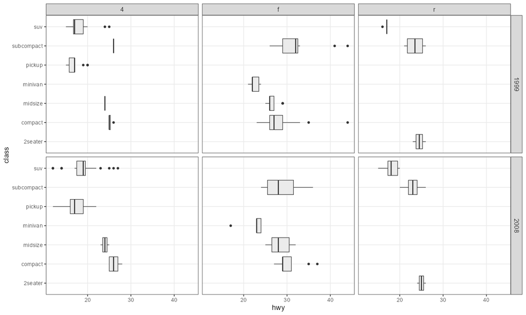

facet_grid(scales = ‘free_y’): the y axis only sits in the left-most column, and a row shares its union

```r
p_caty_n(facet_grid)
```

## Discrete on both axes: everything per panel

```r
p_disc_n <- function(fn = facet_gridn) {
  ggplot(d_disc, aes(class, drv)) +
    geom_count(colour = "grey25", alpha = 0.85) +
    scale_size_area(max_size = 6) +
    fn(vars(year), vars(cylgrp), scales = "free") +
    th_n + theme(axis.text.x = element_text(angle = 45, hjust = 1))
}
```

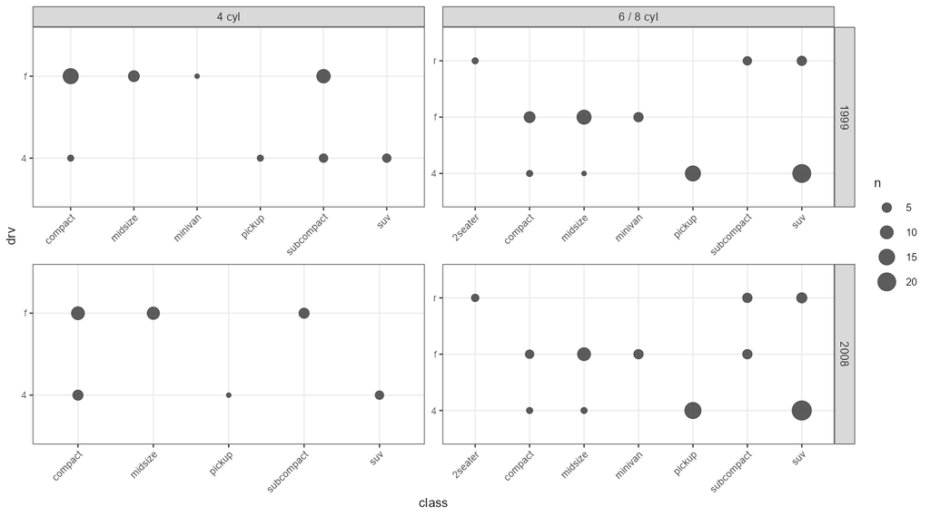

facet_gridn(scales = ‘free’): both axes of every cell list only the categories it contains

```r
p_disc_n()
```

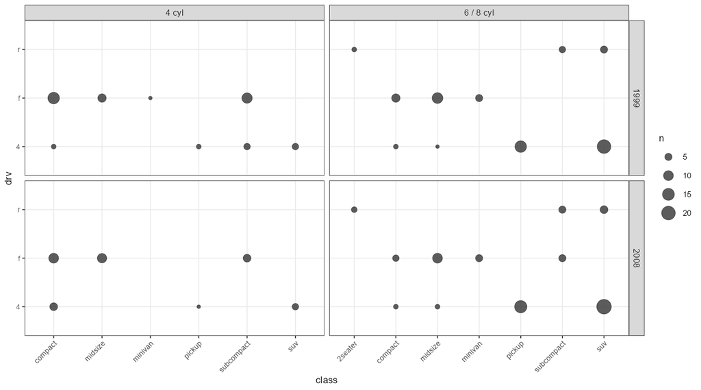

facet_grid(scales = ‘free’): x per column, y per row, leaving unused categories on the axes

```r
p_disc_n(facet_grid)
```

## Panels in rows: `rows = vars(drv)`

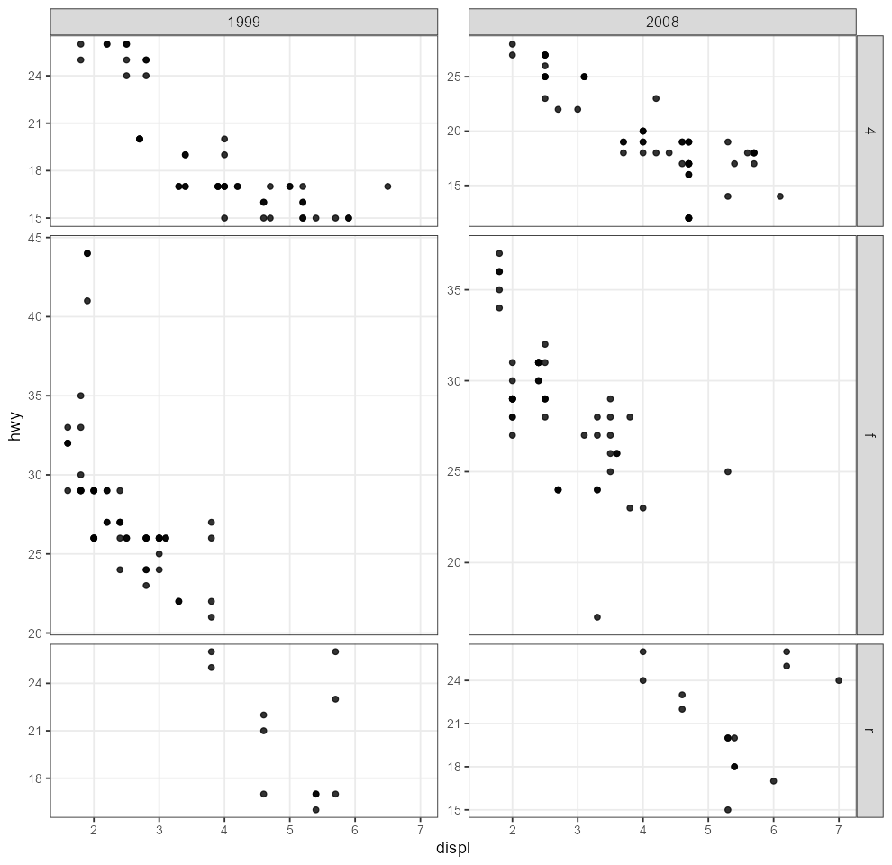

rows = vars(drv), scales = ‘free_y’: every panel gets its own y axis

```r
ggplot(d_cont, aes(displ, hwy)) +
  geom_point(size = 1.2, alpha = 0.8) +
  facet_gridn(rows = vars(drv), cols = vars(year), scales = "free_y",
              space = "free_y") +
  th_n
```

`space = "free_y"` hands each row a height proportional to its y range; switch back to `scales = "fixed"` for a shared axis.

## `space = "free_x"`: panel width follows its own range

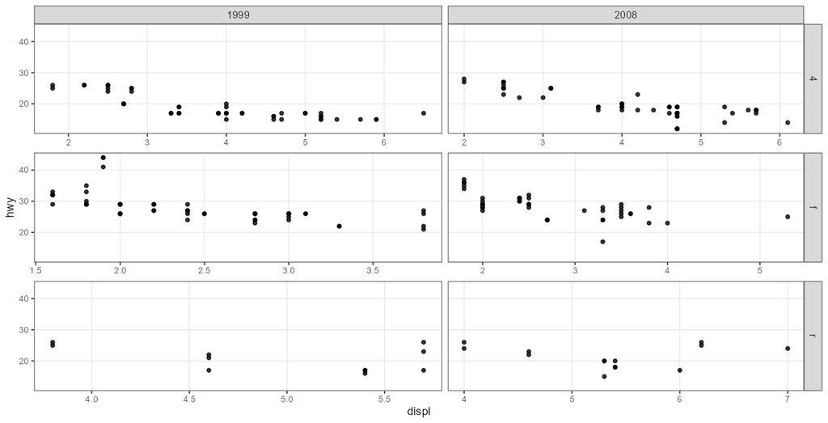

space = ‘free_x’: a wider x range gets a wider panel

```r
ggplot(d_cont, aes(displ, hwy)) +
  geom_point(size = 1.2, alpha = 0.8) +
  facet_gridn(vars(drv), vars(year), scales = "free_x", space = "free_x") +
  th_n
```

## Compatibility values: `free_x_bycol` / `free_y_byrow`

To keep the stock “per column / per row” semantics (say x shared per column but y independent per panel), use these two values:

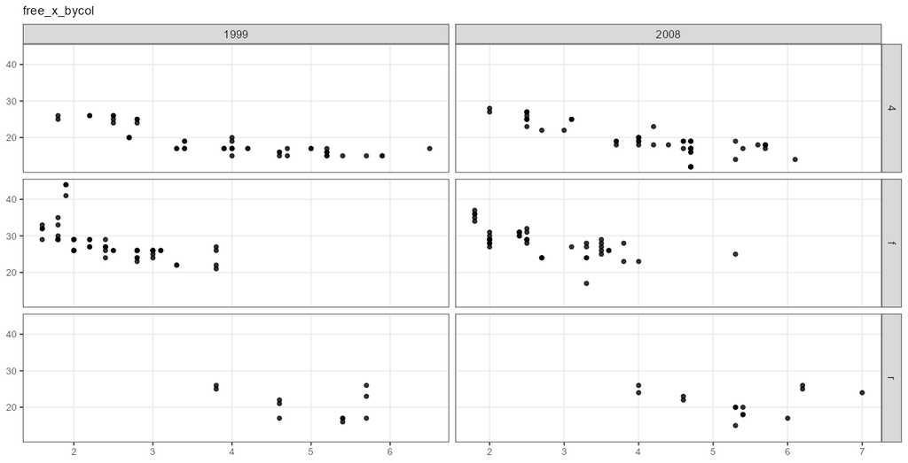

free_x_bycol: the x axis only sits under the bottom row and is shared per column – identical to facet_grid(scales = ‘free_x’)

```r
p_cont_n("free_x_bycol")
```

`free_y_byrow` is the mirror image (y only in the left-most column, shared per row) and matches the stock `free_y`.

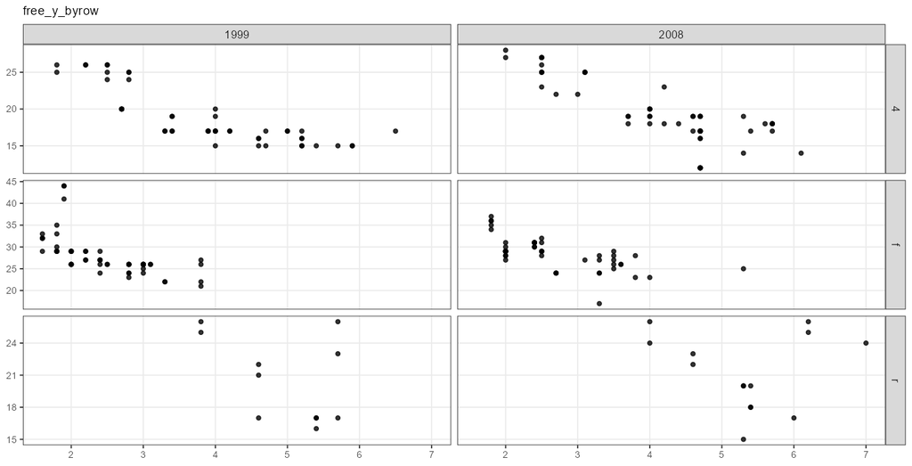

free_y_byrow: the y axis only sits on the left-most column and is shared per row – identical to facet_grid(scales = ‘free_y’)

```r
p_cont_n("free_y_byrow")
```

## Combining with the cluster tree

`scale_x_cluster()` / `scale_y_cluster()` read the facet’s `scales` themselves, so switching to `facet_gridn()` makes the trees per panel as well: one tree per cell, without touching any tree-related code. See “Cluster dendrogram on a discrete axis” below for the examples.

# Spiral coordinates: `coord_spiral()`

`coord_spiral()` bends an ordinary Cartesian ggplot into an Archimedean spiral. The geometry follows the **spiralize** package: the base spiral is r = b·theta and one turn increases the radius by one unit. The x aesthetic runs along the spiral as the angle, y becomes the radius inside the track. Lines, bars, points and areas are supported, the matching angle and radial axes are drawn automatically, and `facet_wrap()` / `facet_grid()` get one spiral per panel.

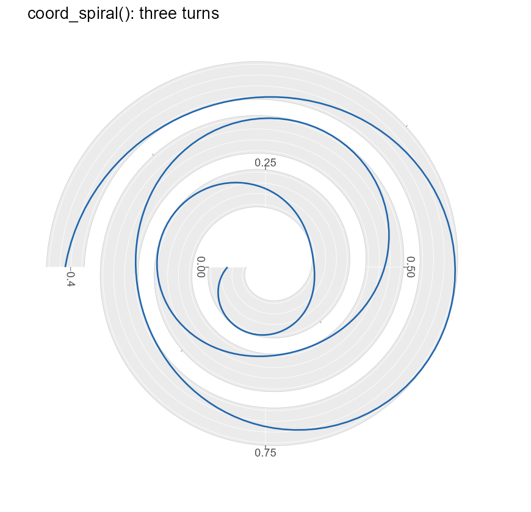

coord_spiral(): a line on three turns, with the angle and radial axes

```r
set.seed(42)
d_sp <- data.frame(
  x = seq(0, 1, length.out = 300),
  y = sin(seq(0, 1, length.out = 300) * 8 * pi) * 0.35 + 0.5
)
ggplot(d_sp, aes(x, y)) +
  geom_line(colour = "#2166ac", linewidth = 0.6) +
  coord_spiral() +
  labs(x = NULL, y = NULL, title = "coord_spiral(): three turns")
```

The main arguments: `start` / `end` are degrees (`360 * n + a` means `n` turns ending at `a`); `period` sets how many x units one turn covers; `height` is the track height as a fraction of the gap between turns; `scale_by = "angle"` (default) maps equal x steps to equal angles, while `"curve"` maps them to equal lengths along the spiral. `clockwise`, `reverse` and `flip` control direction, `labels = FALSE` turns the axes off, and `y_axis_theta` chooses where the radial ruler is placed (the outer end by default).

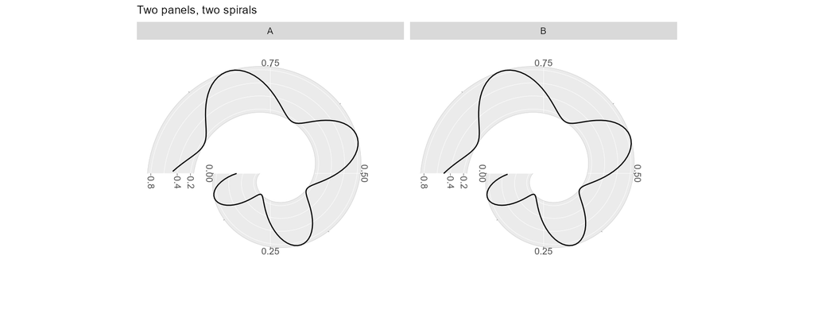

facet_wrap(): one spiral per panel, each with its own axis

```r
d_sp$set <- rep(c("A", "B"), length.out = 300)
ggplot(d_sp, aes(x, y)) +
  geom_line() +
  facet_wrap(~set) +
  coord_spiral(end = 360 + 90) +
  labs(x = NULL, y = NULL, title = "Two panels, two spirals") +
  theme(plot.title = element_text(size = 11))
```

## Spiral heat map: 300 genes x 8 samples

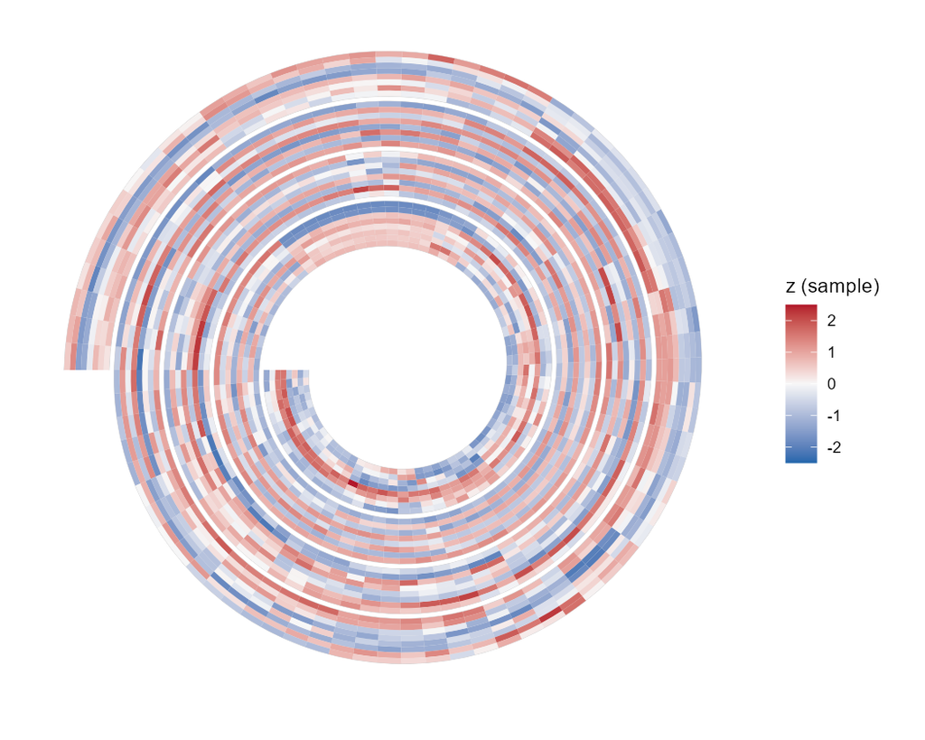

The built-in data as a spiral heat map: 300 genes over four turns, with the eight samples as concentric bands

```r
data(airway_heatmap)
d_hm <- airway_sample_z
d_hm$x <- as.numeric(d_hm$gene)
d_hm$y <- as.numeric(d_hm$sample)

ggplot(d_hm, aes(x, y, fill = z_sample)) +
  geom_tile() +
  scale_fill_gradient2(low = "#2166ac", mid = "#f7f7f7", high = "#b2182b",
                       limits = c(-2.5, 2.5), oob = scales::squish, name = "z (sample)") +
  scale_x_continuous(expand = c(0, 0)) +
  scale_y_continuous(expand = c(0, 0)) +
  coord_spiral(turns = 4, height = .9, inner = .12, labels = FALSE) +
  labs(x = NULL, y = NULL)
```

Three things matter:

- add **`expand = c(0, 0)`** on both scales, otherwise the colour band stops short of the track edges and leaves white slivers at the start and the end;
- make **`inner` larger**; the default `0.04` leaves the innermost turn so small that the cells pile up, `0.10 - 0.12` works well;
- for four turns or more use **`labels = FALSE`** - 300 gene ticks mean nothing; turn them back on at two turns, where the radial ticks label the samples. To label the samples on the radius instead, use two turns, keep the axis and replace the y breaks with the sample names:

```r
ggplot(d_hm, aes(x, y, fill = z_sample)) +
  geom_tile() +
  scale_y_continuous(expand = c(0, 0), breaks = 1:8,
                     labels = paste0("S", 1:8)) +
  scale_x_continuous(expand = c(0, 0)) +
  coord_spiral(turns = 2, height = .85, inner = .1)
```

## An arrow along the spiral (`spiral_arrow()` style)

`spiralize`’s `spiral_arrow(0.2, 0.8)` is just **an x interval interpolated into a `geom_path()` along the track**, plus an arrow head. `geom_path()` is essential: it connects the interpolated points in data order, so the line follows the spiral; `geom_segment()` only has two end points and would cut straight across the panel.

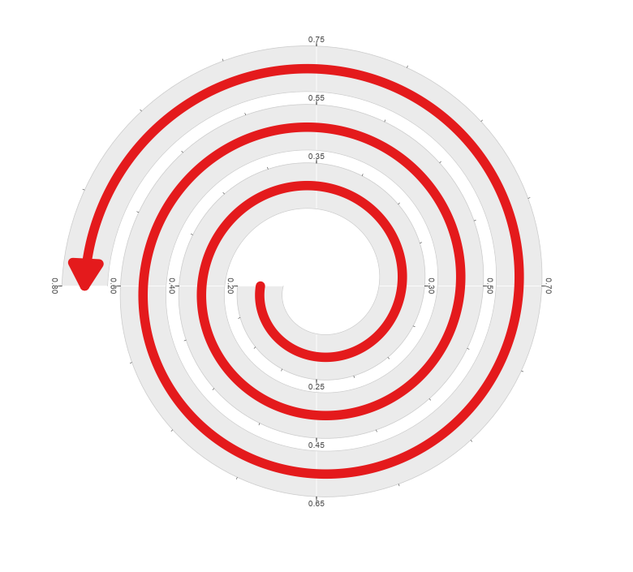

An arrow along the spiral from x = 0.2 to 0.8, with minor ticks between the labelled ones

```r
d_arrow <- data.frame(x = seq(0.2, 0.8, length.out = 900), y = 0.5)

ggplot(d_arrow, aes(x, y)) +
  geom_path(linewidth = 2.6, colour = "#e41a1c", lineend = "round",
            arrow = grid::arrow(length = unit(5.5, "mm"), type = "closed")) +
  scale_x_spiral_axis(breaks = seq(0.2, 0.8, by = 0.05),
                      minor_breaks = seq(0.2, 0.8, by = 0.0125),
                      label_size = 5) +
  scale_y_spiral_axis(show = FALSE) +
  coord_spiral(turns = 3, height = .78, inner = .06, outer = .46, y_axis = FALSE)
```

# Which layers are supported

`coord_spiral()` is an ordinary ggproto `Coord`: all it does is map every point from the data scale to panel coordinates. So **any layer that hands its `x`/`y` to the coordinate transform just works**, with no extra setup.

| Layer | Status | Notes |
| --- | --- | --- |
| `geom_point()` / `geom_jitter()` | works | points land on the track |
| `geom_line()` / `geom_step()` | works | the line is bent along the spiral |
| `geom_path()` | works | connects in data order, so an unordered path loops back |
| `geom_area()` / `geom_ribbon()` | works | both bounds follow the spiral |
| `geom_col()` / `geom_bar()` | works | bars become wedges of the track |
| `geom_histogram()` / `geom_density()` | works | binning and density are fine |
| `geom_smooth()` | works | curve and confidence band both follow the spiral |
| `geom_tile()` | works | heat maps unroll along the spiral (below) |
| `geom_boxplot()` / `geom_violin()` | works | needs a discrete x |
| `geom_text()` / `geom_label()` | works | keep the font small, or the text spans turns |
| `geom_errorbar()` / `geom_pointrange()` / `geom_linerange()` | works | whiskers become short arcs on the track |
| `geom_polygon()` | works | vertices are mapped, edges are straight (see below) |
| `geom_raster()` | falls back | warns that it needs a linear coord and draws via `geom_rect()` |
| `geom_segment()` / `geom_curve()` | works | both ends are transformed, arrows (`arrow =`) included; the edge between them is straight, invisible over short spans |
| `geom_rect()` | works | all four corners are transformed, giving a quad that hugs the track |
| `geom_hline()` / `geom_vline()` / `geom_abline()` | not supported | an infinite line has no end points to transform, so it turns into a closed shape |
| `geom_sf()` / `geom_map()` | not supported | they need `coord_sf()` / their own coord |

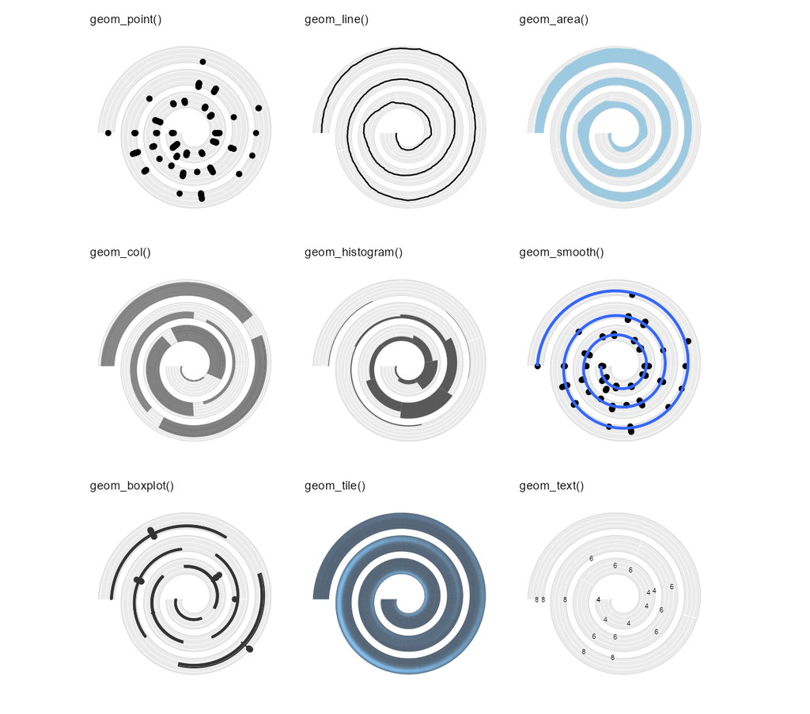

ggplot2’s own layer examples drawn on coord_spiral(): points, line, area, bars, histogram, smooth, boxplot, heat map, text

```r
library(patchwork)

## the layer examples are the ones from the ggplot2 reference pages
sp <- function(p, title) {
  p + coord_spiral(turns = 3, labels = FALSE) +
    labs(x = NULL, y = NULL, title = title) +
    theme(plot.title = element_text(size = 9),
          axis.text = element_text(size = 5),
          legend.position = "none")
}

wrap_plots(
  sp(ggplot(mpg, aes(displ, hwy)) + geom_point(), "geom_point()"),
  sp(ggplot(economics, aes(date, unemploy)) + geom_line(), "geom_line()"),
  sp(ggplot(economics, aes(date, unemploy)) + geom_area(fill = "#9ecae1"), "geom_area()"),
  sp(ggplot(mpg, aes(class, hwy)) + geom_col(), "geom_col()"),
  sp(ggplot(mpg, aes(hwy)) + geom_histogram(binwidth = 2), "geom_histogram()"),
  sp(ggplot(mpg, aes(displ, hwy)) + geom_point() + geom_smooth(), "geom_smooth()"),
  sp(ggplot(mpg, aes(class, hwy)) + geom_boxplot(), "geom_boxplot()"),
  sp(ggplot(faithfuld, aes(waiting, eruptions, fill = density)) +
       geom_tile(), "geom_tile()"),
  sp(ggplot(mpg[seq(1, 234, 12), ], aes(displ, hwy, label = cyl)) +
       geom_text(size = 2), "geom_text()"),
  ncol = 3
)
```

**Why the edges between two points are straight**: the transform is applied to every position aesthetic (`x`, `y`, `xend`, `yend`, `xmin`, `xmax`, `ymin`, `ymax`), but the edge between two transformed points is still a straight segment. Over a short span you cannot see the difference - the figure below is a copy of `spiralize::spiral_segments()`, where every segment spans only 0.02 x units and looks like it lies exactly on the track. Over a long span the chord becomes visible; in that case draw the line with `geom_path()` instead, interpolating intermediate points along the arc and separating the pieces with `group`.

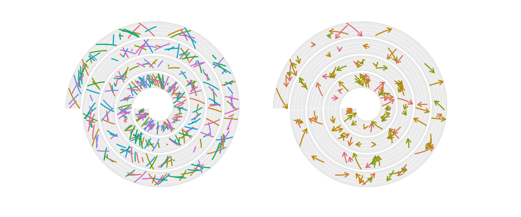

A copy of spiralize’s Segments example: coloured segments on the left, segments with arrow heads on the right

```r
set.seed(2)
n <- 400
d_seg <- data.frame(
  x  = runif(n), y = runif(n)
)
d_seg$xend <- d_seg$x + runif(n, min = -0.01, max = 0.01)
d_seg$yend <- 1 - d_seg$y
d_seg$col <- grDevices::hcl.colors(n, "Dark 3")

p_seg <- ggplot(d_seg, aes(x, y)) +
  geom_segment(aes(xend = xend, yend = yend), colour = d_seg$col,
               linewidth = .6, show.legend = FALSE) +
  coord_spiral(turns = 4, height = .85, labels = FALSE)

p_arrow <- ggplot(d_seg[seq_len(120), ], aes(x, y)) +
  geom_segment(aes(xend = xend, yend = yend), colour = d_seg$col[seq_len(120)],
               linewidth = .6, show.legend = FALSE,
               arrow = arrow(length = unit(2, "mm"))) +
  coord_spiral(turns = 4, height = .85, labels = FALSE)

wrap_plots(p_seg, p_arrow, ncol = 2)
```

## Radial and stacked bars

The `spiralize::spiral_bars()` look comes straight out of `geom_col()`: bars grow from the smallest y (usually 0) towards the outside, and `width` sets how much of the angle they take. Setting `expand` to 0 makes the bars fill the track, with no gap before the first one or after the last one.

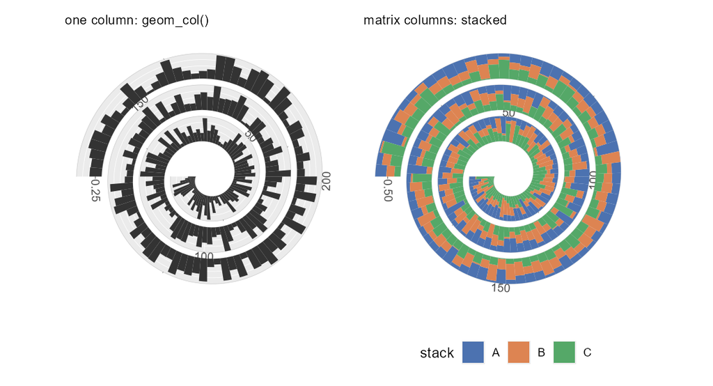

Left: one bar per column. Right: the same data stacked

```r
set.seed(1)

## one value per column
d1 <- data.frame(x = seq_len(240), v = runif(240, .05, 1))
p1 <- ggplot(d1, aes(x, v)) +
  geom_col(width = 1, fill = "grey20") +
  scale_x_continuous(expand = c(0, 0)) +
  scale_y_continuous(expand = c(0, 0)) +
  coord_spiral(turns = 3, height = .8) +
  labs(x = NULL, y = NULL, title = "one column: geom_col()")

## a matrix: one column per stack
n <- 200
m <- matrix(runif(3 * n), ncol = 3)
m <- m / rowSums(m)
d2 <- data.frame(x = rep(seq_len(n), 3),
                 stack = factor(rep(c("A", "B", "C"), each = n)),
                 v = as.vector(m))
p2 <- ggplot(d2, aes(x, v, fill = stack)) +
  geom_col(width = 1) +
  scale_fill_manual(values = c("#4C72B0", "#DD8452", "#55A868")) +
  scale_x_continuous(expand = c(0, 0)) +
  scale_y_continuous(expand = c(0, 0)) +
  coord_spiral(turns = 3, height = .8) +
  labs(x = NULL, y = NULL, title = "matrix columns: stacked")

wrap_plots(p1, p2, ncol = 2) &
  theme(plot.title = element_text(size = 10), legend.position = "bottom")
```

Stacking works because y *is* the radius inside the track: `position = "stack"` stacks the pieces along the radius, so every column of the matrix becomes one concentric band. In the same way `position = "dodge"` spreads the bars along the angle, and `position = "fill"` normalises them to the track width.

# Cluster dendrogram on a discrete axis

`guide_axis_cluster()` adds a hierarchical clustering dendrogram to an x or y discrete axis; the companion `scale_x_cluster()` / `scale_y_cluster()` reorder the categories into dendrogram leaf order. The key point: the companion scale sets `limits` to the clustered order, so **both the axis labels and the data in the plot are reordered together** and the tree stays aligned with the data – there is no “labels changed but cells stayed put” mismatch.

```r
set.seed(1)
mat <- matrix(rnorm(12 * 4), nrow = 12,
              dimnames = list(paste0("g", 1:12), paste0("s", 1:4)))
long <- as.data.frame(as.table(mat))
names(long) <- c("gene", "sample", "value")
```

A rectangular dendrogram on the y axis (`type = "rectangle"`, the default); `method` selects the clustering method, `height` is the overall tree height in centimetres, and `col` sets the line colour:

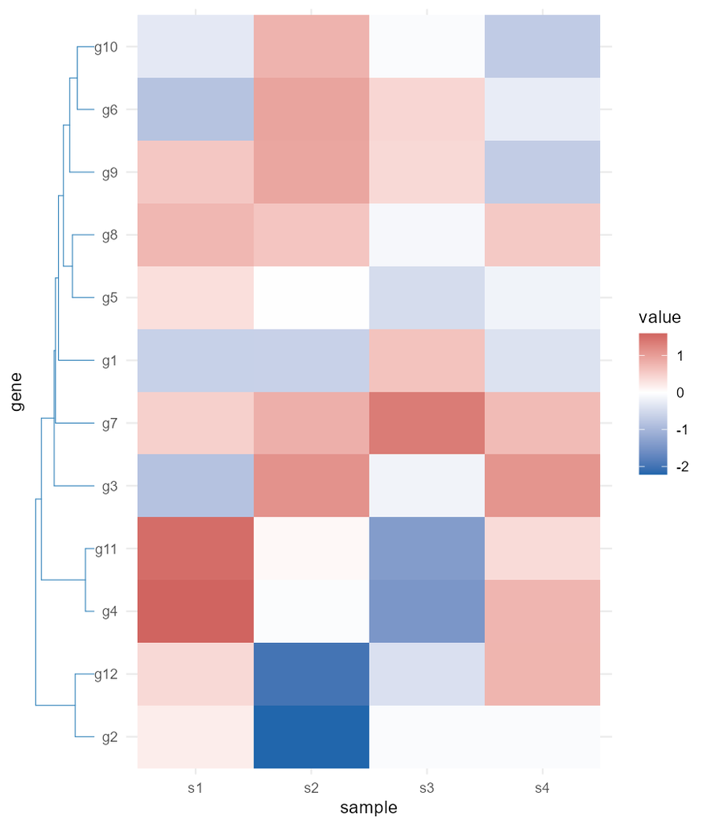

Rectangular cluster tree on the y axis; genes are reordered by clustering

```r
ggplot(long, aes(sample, gene, fill = value)) +
  geom_tile() +
  scale_y_cluster(mat, method = "average", height = 1.4, col = "#2c7fb8") +
  scale_fill_gradient2(low = "#2166ac", mid = "white", high = "#b2182b", midpoint = 0) +
  theme_minimal(base_size = 11)
```

The triangular tree (`type = "triangle"`) converges to a single vertex at every merge, drawn like `plot(as.dendrogram(hc), type = "triangle")`:

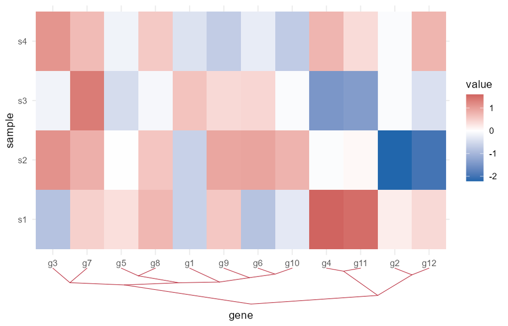

Triangular cluster tree on the x axis

```r
ggplot(long, aes(gene, sample, fill = value)) +
  geom_tile() +
  scale_x_cluster(mat, method = "ward.D2", height = 1.4,
                  col = "#b2182b", type = "triangle") +
  scale_fill_gradient2(low = "#2166ac", mid = "white", high = "#b2182b", midpoint = 0) +
  theme_minimal(base_size = 11)
```

## `method`: a different linkage, a different tree

`method` goes straight to `stats::hclust()`. The two figures above use `average` and `ward.D2`; switch to `"single"` (nearest-neighbour chaining) and the tree collapses into a chain, with the leaves re-ordered as well:

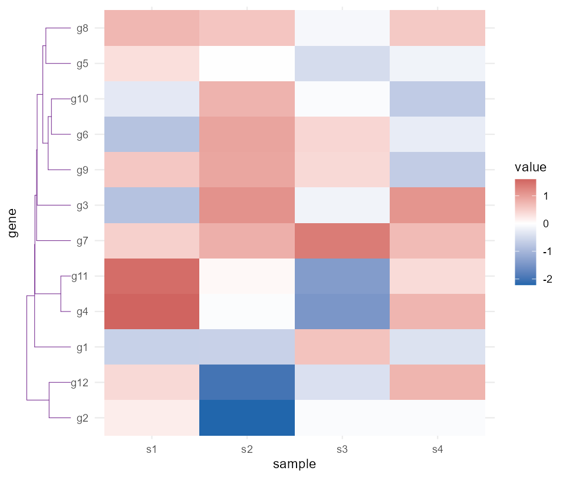

method = ‘single’: chaining gives a visibly different tree from average / ward.D2

```r
ggplot(long, aes(sample, gene, fill = value)) +
  geom_tile() +
  scale_y_cluster(mat, method = "single", height = 1.4, col = "#7b3294") +
  scale_fill_gradient2(low = "#2166ac", mid = "white", high = "#b2182b",
                       midpoint = 0) +
  theme_minimal(base_size = 11)
```

## A tree on both axes

`scale_x_cluster()` clusters the columns, `scale_y_cluster()` the rows; the two trees stay out of each other’s way and both axes are re-ordered:

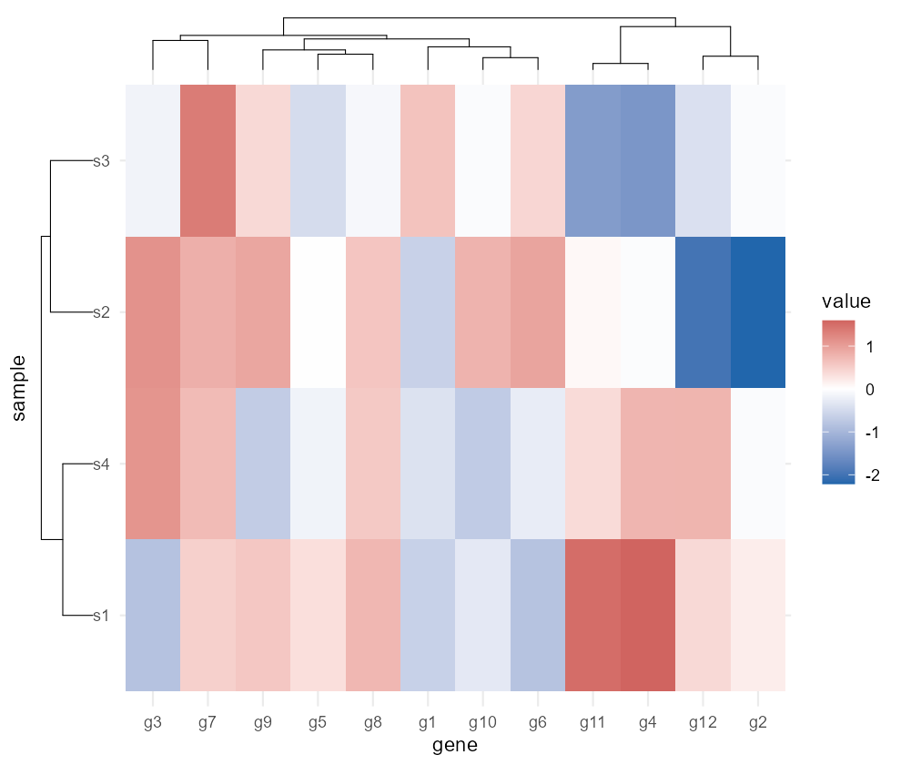

x tree on top, y tree on the left: rows and columns both in cluster order

```r
ggplot(long, aes(gene, sample, fill = value)) +
  geom_tile() +
  scale_x_cluster(position = "top", height = 1.1) +
  scale_y_cluster(position = "left", height = 1.1) +
  scale_fill_gradient2(low = "#2166ac", mid = "white", high = "#b2182b",
                       midpoint = 0) +
  theme_minimal(base_size = 11)
```

To get just the clustered order without the companion scale, use `cluster_order()`, e.g. `scale_y_discrete(limits = cluster_order(mat))`.

## `position`: move the tree, not the labels

`position` decides **which side the tree is drawn on**; the labels never move:

| axis | `position` | tree | labels |
| --- | --- | --- | --- |
| x | `"bottom"` (default) | outside the labels, by the `gene` title | still at the bottom |
| x | `"top"` | above the panel; with facets, **under the strip** | still at the bottom |
| y | `"left"` (default) | left of the labels | still on the left |
| y | `"right"` | at the end of the panel row | still on the left |

```r
tile_x <- function(pos) {
  ggplot(long, aes(gene, sample, fill = value)) +
    geom_tile() +
    scale_fill_gradient2(low = "#2166ac", mid = "white", high = "#b2182b",
                         midpoint = 0) +
    scale_x_cluster(position = pos, height = 1) +
    theme_minimal(base_size = 11)
}
tile_y <- function(pos) {
  ggplot(long, aes(sample, gene, fill = value)) +
    geom_tile() +
    scale_fill_gradient2(low = "#2166ac", mid = "white", high = "#b2182b",
                         midpoint = 0) +
    scale_y_cluster(position = pos, height = 1) +
    theme_minimal(base_size = 11)
}
```

x tree on top, labels still at the bottom:

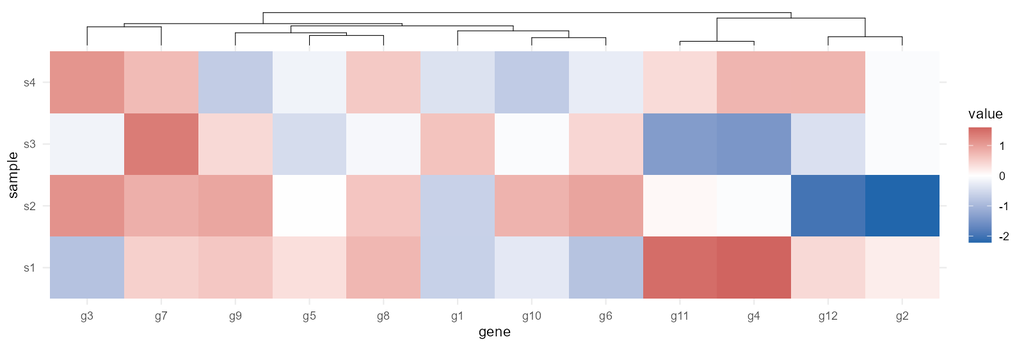

position = ‘top’: tree above the panel, x labels stay at the bottom

```r
tile_x("top")
```

y tree on the left, left of the labels:

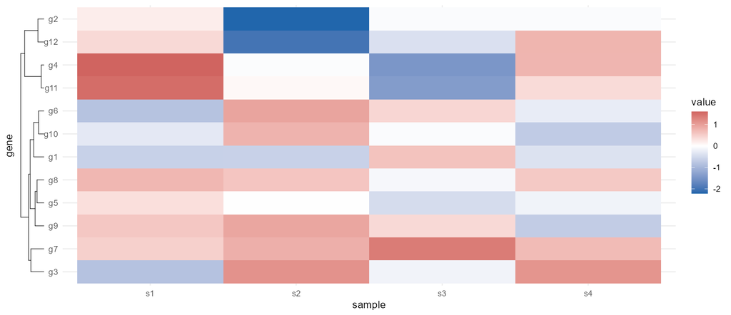

position = ‘left’: tree left of the y labels

```r
tile_y("left")
```

y tree on the right, at the end of the panel row:

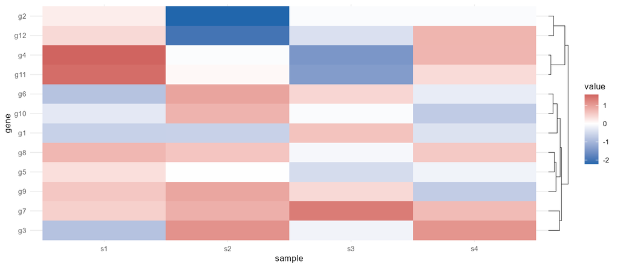

position = ‘right’: tree to the right of the panel

```r
tile_y("right")
```

The tree can leave the labels because it no longer goes through a secondary axis: it is drawn straight into the final gtable, the only place that knows the geometry of every panel. That is also why `facet_grid()` works – row facets own the y axis and column facets own the x axis, so each tree lands under its own strip.

## No matrix needed

```r
ggplot(d, aes(gene, sample, fill = zscore, size = pct)) +
  geom_point() +
  scale_x_cluster(value = "zscore")   # defaults to the first numeric aesthetic
```

Changing `value =` changes the tree as well. The dot plot below carries both `fill` (expression) and `size` (fraction expressed); clustering on one or the other gives different trees:

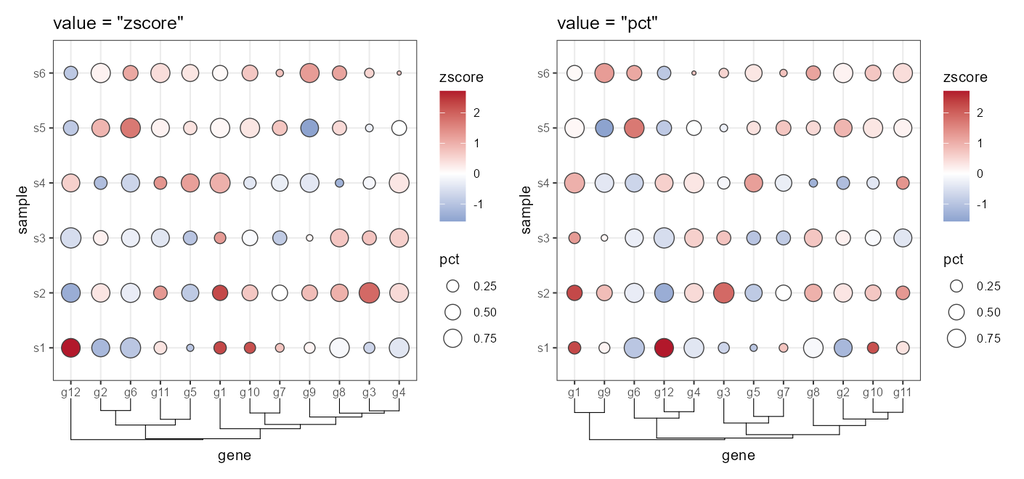

One dot plot, clustered on fill (left) and on size (right): the trees differ

```r
set.seed(7)
d_val <- expand.grid(gene = paste0("g", 1:12), sample = paste0("s", 1:6))
d_val$zscore <- stats::rnorm(nrow(d_val))
d_val$pct <- stats::runif(nrow(d_val), 0, 1)
p_val <- function(v) {
  ggplot(d_val, aes(gene, sample, fill = zscore, size = pct)) +
    geom_point(shape = 21, colour = "grey25") +
    scale_x_cluster(value = v, height = 1.1) +
    scale_fill_gradient2(low = "#2166ac", mid = "white", high = "#b2182b") +
    labs(title = paste0("value = \"", v, "\"")) +
    theme_bw(base_size = 10)
}
wrap_plots(p_val("zscore"), p_val("pct"), nrow = 1)
```

## Facets: one tree per panel

A single-cell dot plot is usually faceted by cell type, and every panel holds a different gene set. Hand `scales` to the facet and the tree is recomputed per panel automatically – no `free = TRUE` needed:

```r
data(pbmc3k_dotplot)
d4 <- droplevels(pbmc3k_dotplot[pbmc3k_dotplot$celltype %in%
                                  c("Naive CD4 T", "CD14+ Mono", "NK", "B"), ])
d4$cluster_id <- factor(d4$cluster_id)      # cluster id on y: 0 / 1 / 3 / 6
top_of <- function(x, k) head(x$gene[order(-x$avg_exp_scaled)], k)

dot_layers <- function() {
  list(
    geom_point(aes(size = pct_expressed, fill = avg_exp_scaled),
               shape = 21, colour = "black", stroke = 0.25),
    scale_fill_gradient2(low = "#2166ac", mid = "#f7f7f7", high = "#b2182b"),
    theme_bw(base_size = 10),
    theme(axis.text.x = element_text(angle = 45, hjust = 1),
          panel.grid.minor = element_blank())
  )
}

genes_by_ct <- lapply(split(d4, d4$celltype), top_of, k = 4)
d_panel <- do.call(rbind, lapply(names(genes_by_ct), function(ct) {
  x <- d4[d4$gene %in% genes_by_ct[[ct]], ]
  x$panel <- ct
  x
}))
d_panel$panel <- factor(d_panel$panel, levels = names(genes_by_ct))
```

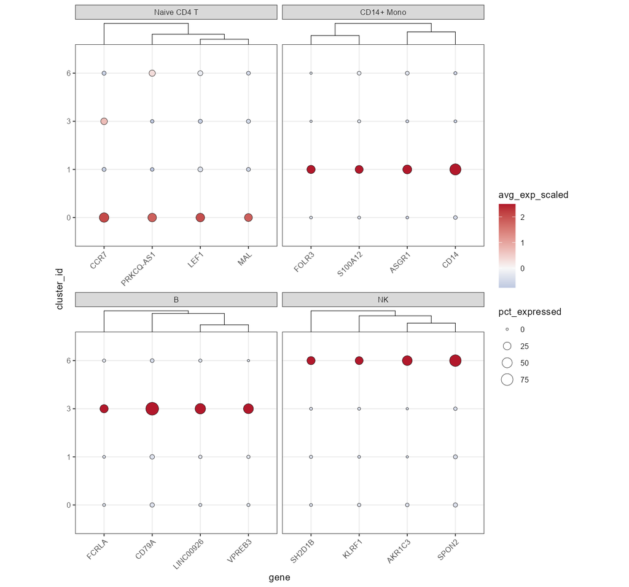

facet_wrap(scales = ‘free_x’): one x tree per panel, tucked under its own strip

```r
ggplot(d_panel, aes(gene, cluster_id)) + dot_layers() +
  facet_wrap(~ panel, scales = "free_x") +
  scale_x_cluster(position = "top", height = 0.9) +
  theme(aspect.ratio = 1)
```

## The four `scales` modes: when the tree is recomputed

`facet_wrap()` / `facet_grid()` `scales` are picked up automatically; whether the tree is recomputed per panel depends only on whether that axis is free:

| `scales` | x axis | y axis | x tree | y tree |
| --- | --- | --- | --- | --- |
| `"fixed"` | shared | shared | one tree for all panels | one per axis |
| `"free_x"` | per panel | shared | one per panel column | one per axis |
| `"free_y"` | shared | per panel | one tree for all panels | one per panel row |
| `"free"` | per panel | per panel | one per panel column | one per panel row |

```r
sets <- list("All four" = c("Naive CD4 T", "CD14+ Mono", "NK", "B"),
             "T + Mono" = c("Naive CD4 T", "CD14+ Mono"),
             "NK + B"   = c("NK", "B"))
d_xy <- do.call(rbind, lapply(names(sets), function(p) {
  x <- d4[d4$celltype %in% sets[[p]] & d4$gene %in% genes_by_ct[[sets[[p]][1]]], ]
  x$panel <- p
  x
}))
d_xy$panel <- factor(d_xy$panel, levels = names(sets))
```

By default the tree is inserted **between the strip and the panel**, with a small gap to the strip (`options(ggutils.tree_gap = 0.14)`, centimetres). Add `strip_side` to move it outside the strip instead:

```r
scale_x_cluster(position = "top", strip_side = "above")
```

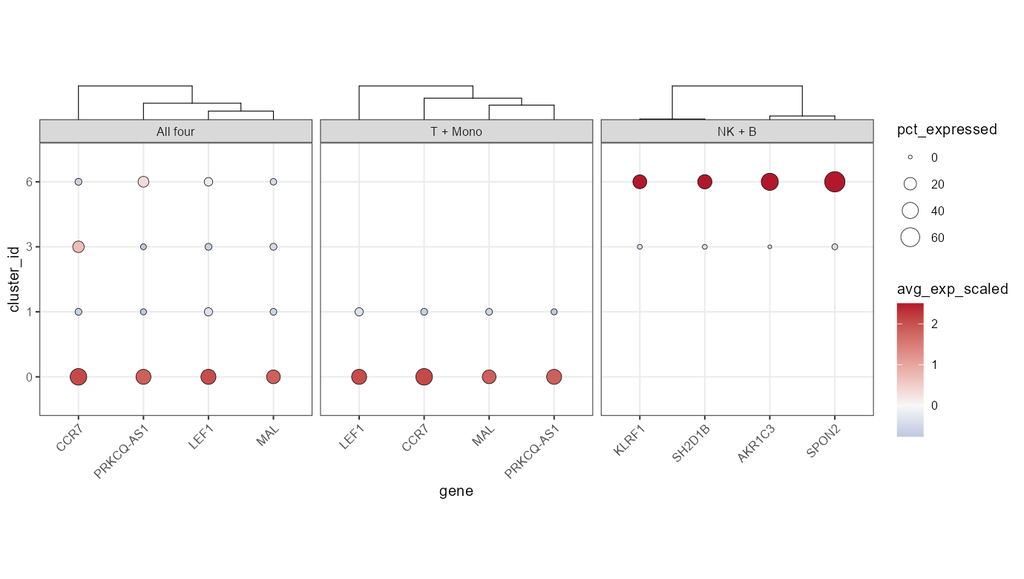

strip_side = ‘above’: the tree moves outside the strip, which stays flush with the panel

```r
ggplot(d_xy, aes(gene, cluster_id)) + dot_layers() +
  facet_wrap(~ panel, nrow = 1, scales = "free_x") +
  scale_x_cluster(position = "top", height = 0.9, strip_side = "above") +
  theme(aspect.ratio = 1)
```

`free_x`: each panel has its own gene set, so each x tree is computed on its own, while the y axis stays shared:

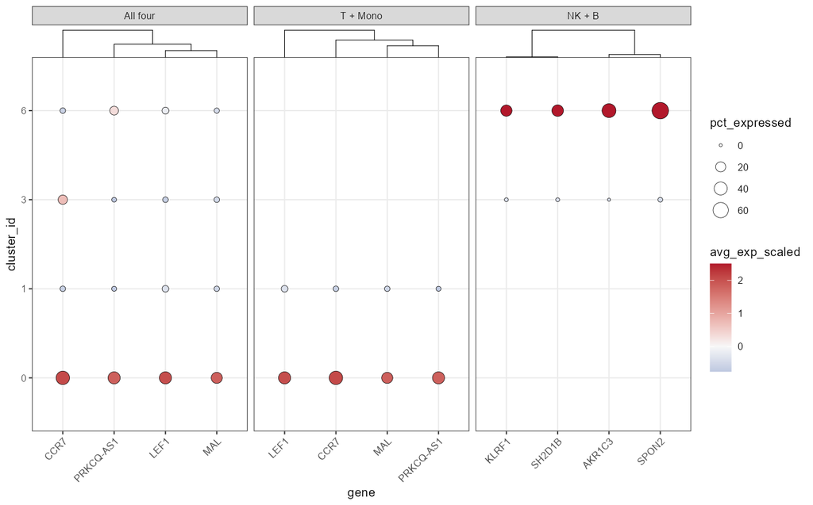

scales = ‘free_x’: per-panel x trees

```r
ggplot(d_xy, aes(gene, cluster_id)) + dot_layers() +
  facet_wrap(~ panel, scales = "free_x") +
  scale_x_cluster(position = "top", height = 0.9)
```

`free_y`: x shared, y per panel, and the y tree becomes one per panel as well, hugging its own cluster labels:

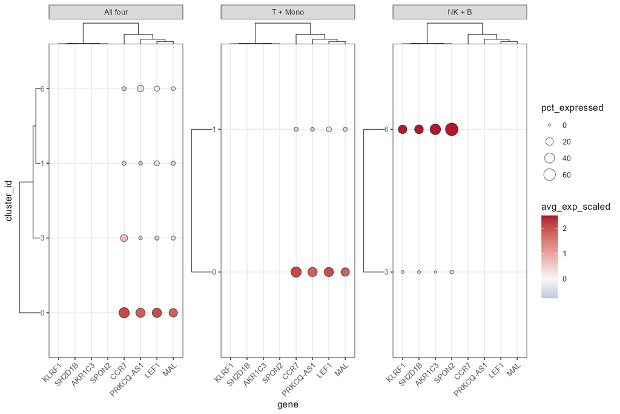

scales = ‘free_y’: shared x tree, per-panel y trees

```r
ggplot(d_xy, aes(gene, cluster_id)) + dot_layers() +
  facet_wrap(~ panel, scales = "free_y") +
  scale_x_cluster(position = "top", height = 0.9) +
  scale_y_cluster(position = "left", height = 0.9)
```

Freeing both directions *and* adding a y tree squeezes the panels very thin; usually keep one direction. See the acceptance report in the package for the full comparison.

## Multi-row facets: each row owns its own strip

With `nrow = 2` the trees are inserted row by row, so the second row’s trees never bleed into the first:

```r
## four panels of two cell types each (= two clusters), same size, to show the layout
sets2 <- list("T + Mono"  = c("Naive CD4 T", "CD14+ Mono"),
              "NK + B"    = c("NK", "B"),
              "Mono + B"  = c("CD14+ Mono", "B"),
              "T + NK"    = c("Naive CD4 T", "NK"))
d_grid <- do.call(rbind, lapply(names(sets2), function(p) {
  x <- d4[d4$celltype %in% sets2[[p]] & d4$gene %in% genes_by_ct[[sets2[[p]][1]]], ]
  x$panel <- p
  x
}))
d_grid$panel <- factor(d_grid$panel, levels = names(sets2))
```

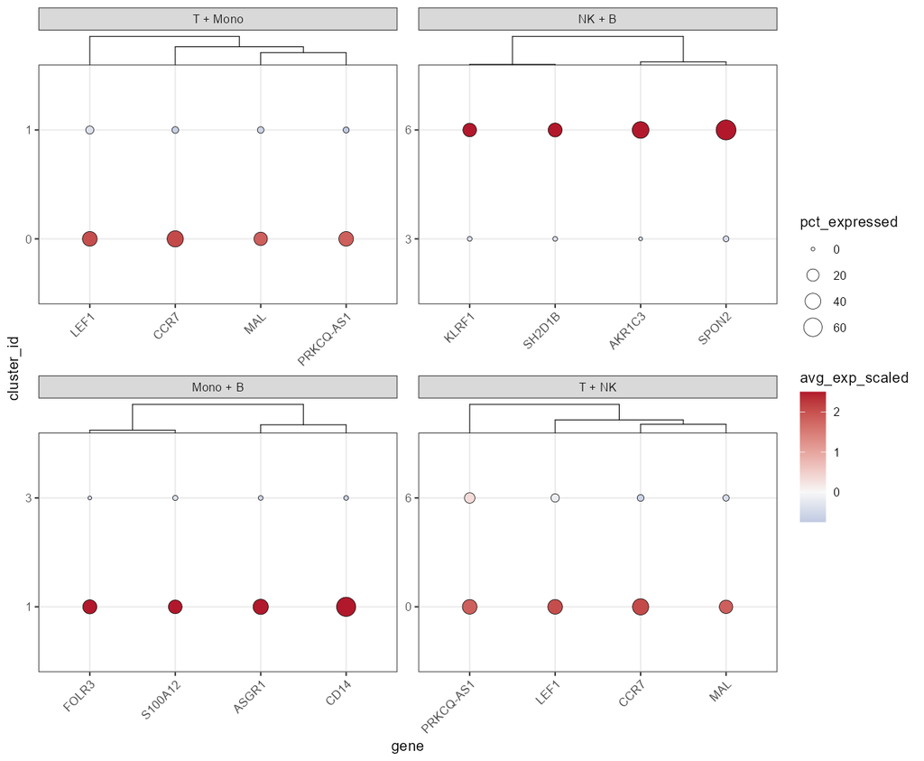

facet_wrap(nrow = 2): the 4 x trees land under their own panel’s strip

```r
ggplot(d_grid, aes(gene, cluster_id)) + dot_layers() +
  facet_wrap(~ panel, scales = "free", nrow = 2) +
  scale_x_cluster(position = "top", height = 0.8)
```

## `facet_grid()`: rows own y, columns own x

In `facet_grid()` the row facet decides y and the column facet decides x, so the **x tree sits under the column strip and the y tree on the left of each row**. Add two categorical columns and build a 2x2: `grp` splits the clusters in two (rows) and `prog` splits the genes into two marker sets (columns):

```r
prog_a <- unique(unlist(lapply(c("Naive CD4 T", "CD14+ Mono"),
                               function(ct) top_of(d4[d4$celltype == ct, ], 3))))
prog_b <- unique(unlist(lapply(c("NK", "B"),
                               function(ct) top_of(d4[d4$celltype == ct, ], 3))))
d_fg <- d4[d4$gene %in% c(prog_a, prog_b), ]
d_fg$grp <- factor(ifelse(as.character(d_fg$cluster_id) %in% c("0", "1"),
                          "c0 / c1", "c3 / c6"), levels = c("c0 / c1", "c3 / c6"))
d_fg$prog <- factor(ifelse(d_fg$gene %in% prog_a, "T / Mono", "NK / B"),
                    levels = c("T / Mono", "NK / B"))
```

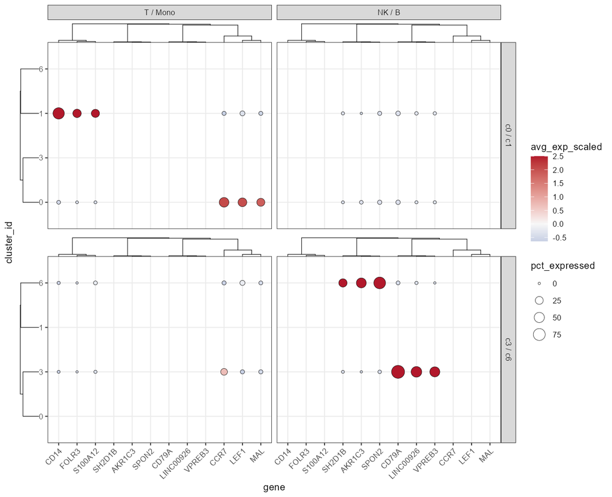

facet_grid(grp ~ prog): x tree under the column strip, y tree left of each row

```r
ggplot(d_fg, aes(gene, cluster_id)) + dot_layers() +
  facet_grid(grp ~ prog, scales = "fixed", drop = FALSE) +
  scale_x_cluster(position = "top", height = 0.8) +
  scale_y_cluster(position = "left", height = 0.8)
```

Two things to keep in mind: `drop = FALSE` is there **to make `fixed` visible** – a discrete y axis drops empty levels per panel by default, and once it does, `fixed` and `free_y` look identical; without dropping, `fixed` tiles all clusters into every panel. And **the number of y trees does not change with `free` inside `facet_grid()`**, because the row itself is the y facet, so every row always has one y axis – `fixed` vs `free_y` only changes how many leaves a tree has.

## An RNA-seq heatmap: faceted by gene set, one y tree per panel

Below: the 18 strongest genes of each set, faceted by `gene_set` with `scales = "free_y"` so every panel lays out only its own genes – and therefore gets its own y tree. The sample axis gets one x tree, which clusters the treatment and control samples into two branches:

```r
data(airway_heatmap, package = "ggutils")
gs <- airway_heatmap$genes
top_set <- do.call(rbind, lapply(split(gs, gs$gene_set), function(d) {
  head(d[order(-abs(d$delta)), ], 18)
}))
d_hm <- droplevels(airway_sample_z[airway_sample_z$gene %in% top_set$gene, ])
```

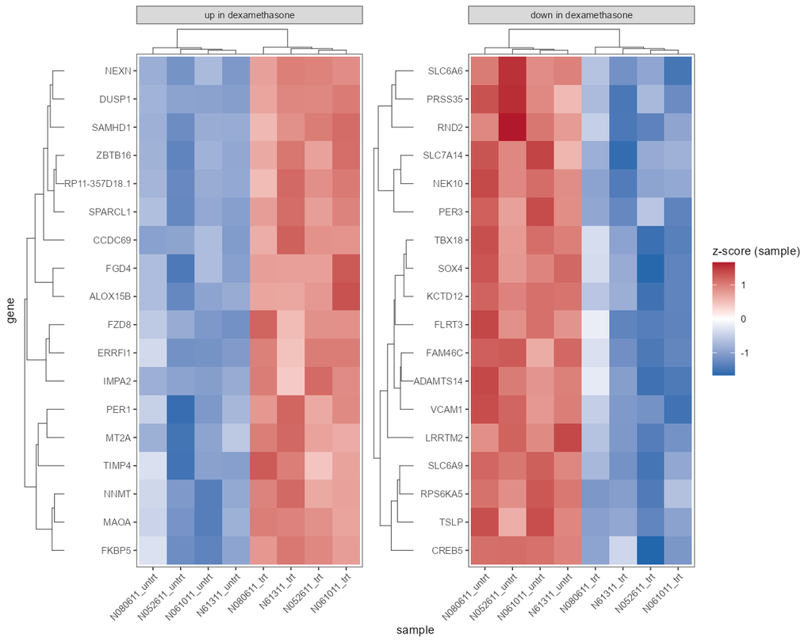

Airway heatmap faceted by gene set: one y tree per panel plus a sample x tree on top

```r
ggplot(d_hm, aes(sample, gene, fill = z_sample)) +
  geom_tile() +
  facet_wrap(~ gene_set, scales = "free_y", nrow = 1) +
  scale_x_cluster(position = "top", height = 0.8, col = "grey25") +
  scale_y_cluster(position = "left", height = 1.2, col = "grey25") +
  scale_fill_gradient2(low = "#2166ac", mid = "white", high = "#b2182b",
                       midpoint = 0, name = "z-score (sample)") +
  theme_bw(base_size = 9) +
  theme(axis.text.x = element_text(angle = 45, hjust = 1),
        panel.grid = element_blank())
```

## Radial coordinates: ring trees on the theta axis, arc tree on the r axis

Around a circle there is no “row above the panel” to put a tree in, so on a `coord_radial()` theta axis `scale_x_cluster()` draws a **ring dendrogram**: leaves sit on a ring, every merge is an arc at another radius joined to its children by radial stubs (`type = "triangle"` uses straight chords to the merge point instead). The labels keep their normal `guide_axis_theta()` look.

`position` decides which side the ring tree goes to:

| `position` | tree drawn | notes |
| --- | --- | --- |
| `"bottom"` (default) | **inside the hole** | leaves on the inner circle, merges towards the centre; needs `inner.radius > 0`, a pie without a hole is skipped |
| `"top"` | **outside the circle** | leaves on the outer circle, merges outwards; `ring_gap` is measured from the labels and the panel is padded automatically |

Ring tree inside the hole (a donut heat map):

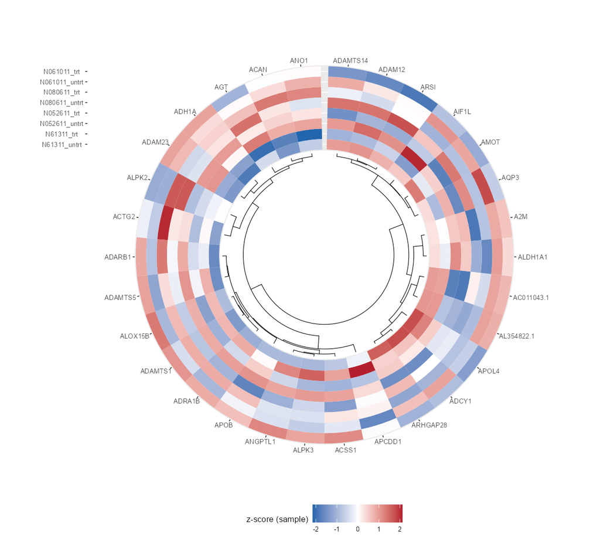

coord_radial(inner.radius = 0.55) + position = ‘bottom’: tree inside the hole, merges towards the centre

```r
data(airway_heatmap, package = "ggutils")
d_ring <- droplevels(
  airway_sample_z[airway_sample_z$gene %in% unique(airway_sample_z$gene)[1:30], ]
)
ggplot(d_ring, aes(gene, sample, fill = z_sample)) +
  geom_tile() +
  coord_radial(theta = "x", inner.radius = 0.55) +
  scale_x_cluster(method = "ward.D2", height = 1.1) +
  scale_fill_gradient2(low = "#2166ac", mid = "white", high = "#b2182b",
                       midpoint = 0, name = "z-score (sample)") +
  theme_grey(base_size = 8) +
  theme(plot.margin = margin(0.6, 0.6, 0.6, 0.6, "cm"),
        legend.position = "bottom") +
  labs(x = NULL, y = NULL)
```

`position = "top"` puts the same tree outside the circle; the leaf ring starts after the labels and the panel gets extra room automatically:

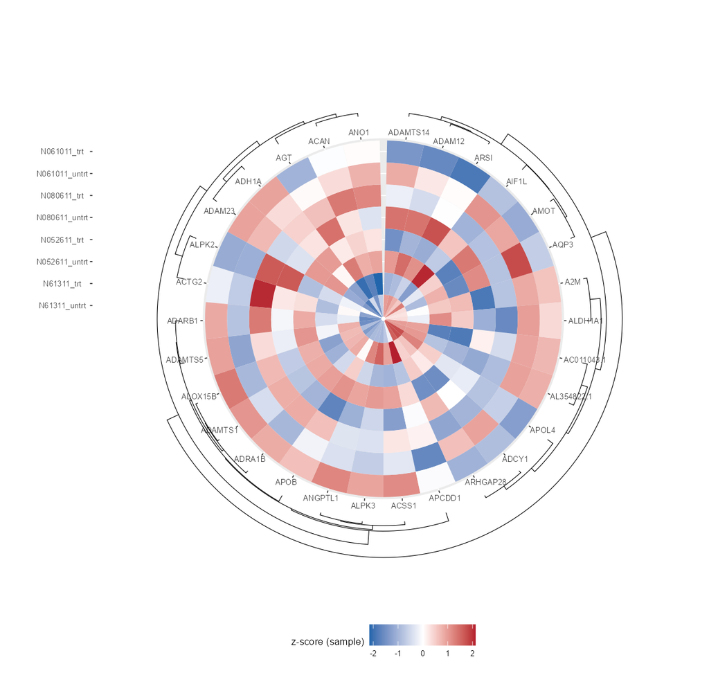

coord_radial() + position = ‘top’: tree outside the circle, merges outwards

```r
ggplot(d_ring, aes(gene, sample, fill = z_sample)) +
  geom_tile() +
  coord_radial(theta = "x") +
  scale_x_cluster(method = "ward.D2", height = 1, position = "top") +
  scale_fill_gradient2(low = "#2166ac", mid = "white", high = "#b2182b",
                       midpoint = 0, name = "z-score (sample)") +
  theme_grey(base_size = 8) +
  theme(plot.margin = margin(0.8, 0.8, 0.8, 0.8, "cm"),
        legend.position = "bottom") +
  labs(x = NULL, y = NULL)
```

Facets work like the cartesian ones – one tree per panel, clustered from that panel’s own genes when the theta scale is free (`free_x` / `free`):

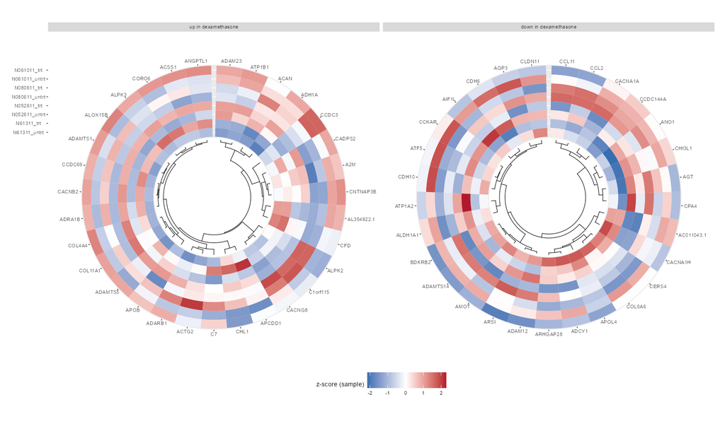

facet_wrap(scales = ‘free_x’) + coord_radial: one inner ring tree per panel

```r
d_ring2 <- droplevels(
  airway_sample_z[airway_sample_z$gene %in% unique(airway_sample_z$gene)[1:60], ]
)
ggplot(d_ring2, aes(gene, sample, fill = z_sample)) +
  geom_tile() +
  facet_wrap(~ gene_set, scales = "free_x") +
  coord_radial(theta = "x", inner.radius = 0.45) +
  scale_x_cluster(method = "ward.D2", height = 0.8) +
  scale_fill_gradient2(low = "#2166ac", mid = "white", high = "#b2182b",
                       midpoint = 0, name = "z-score (sample)") +
  theme_grey(base_size = 7) +
  theme(plot.margin = margin(0.4, 0.4, 0.4, 0.4, "cm"),
        legend.position = "bottom") +
  labs(x = NULL, y = NULL)
```

### Arc tree on the r (y) axis

On a full circle the r axis is just a column of labels, so `scale_y_cluster()` draws **no** tree there. With a partial arc (`start` / `end`) ggplot2 puts the sample labels on a radial ray, and `scale_y_cluster()` then draws an **arc-shaped wedge tree** at the other end of the arc – the side without labels:

- leaf position -> radius: every sample lines up with its own ring;
- merge height -> angle: `height` sets the angular width (`min(pi/3, 0.30 * height)` radians);
- equal-height branches are concentric arcs and the leaf stubs hug the tiles, so the whole tree is made of arcs.

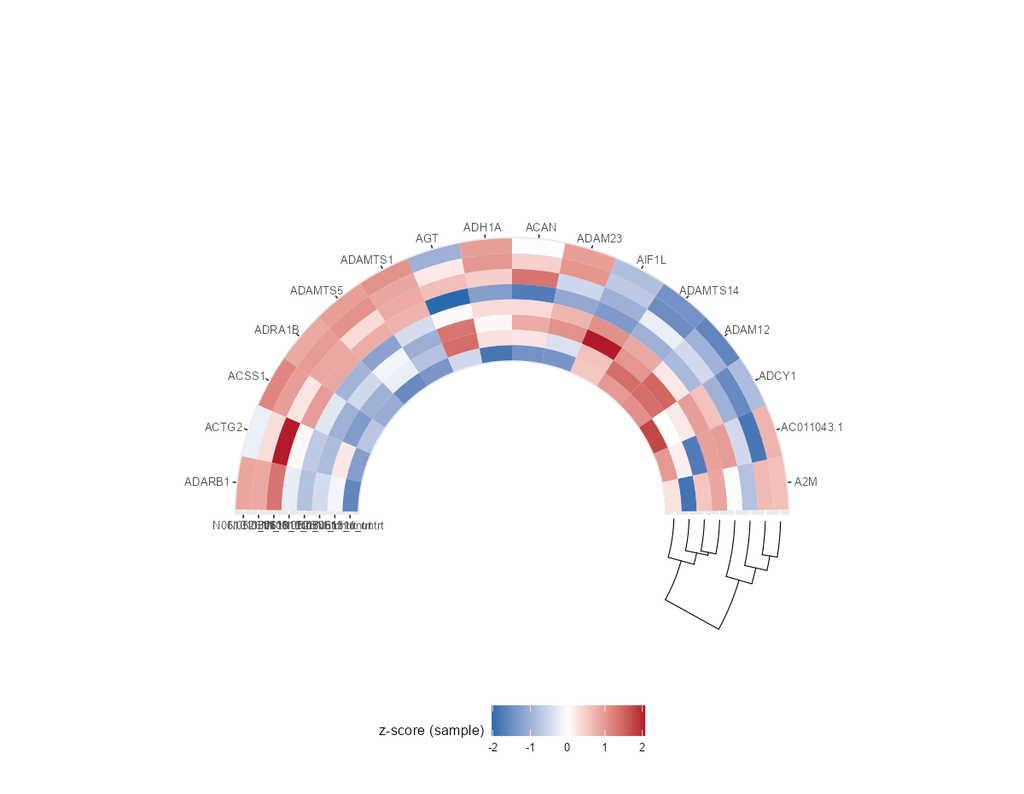

180 degree arc + scale_y_cluster(): arc tree at the label-free end of the arc

```r
d_ring_y <- droplevels(
  airway_sample_z[airway_sample_z$gene %in% unique(airway_sample_z$gene)[1:16], ]
)
ggplot(d_ring_y, aes(gene, sample, fill = z_sample)) +
  geom_tile() +
  coord_radial(theta = "x", start = -0.5 * pi, end = 0.5 * pi,
               inner.radius = 0.55) +
  scale_y_cluster(method = "ward.D2", height = 1.6) +
  scale_fill_gradient2(low = "#2166ac", mid = "white", high = "#b2182b",
                       midpoint = 0, name = "z-score (sample)") +
  theme_grey(base_size = 8) +
  theme(plot.margin = margin(0.6, 0.6, 0.6, 0.6, "cm"),
        legend.position = "bottom") +
  labs(x = NULL, y = NULL)
```

90/270 degree arcs work the same way, only `start` / `end` change, and the r-axis tree can be combined with an x tree on the same plot.

## Facet scales: the trees follow the facet

`facet_gridn(scales = "free_x")` is per panel, so every cell gets its own x tree:

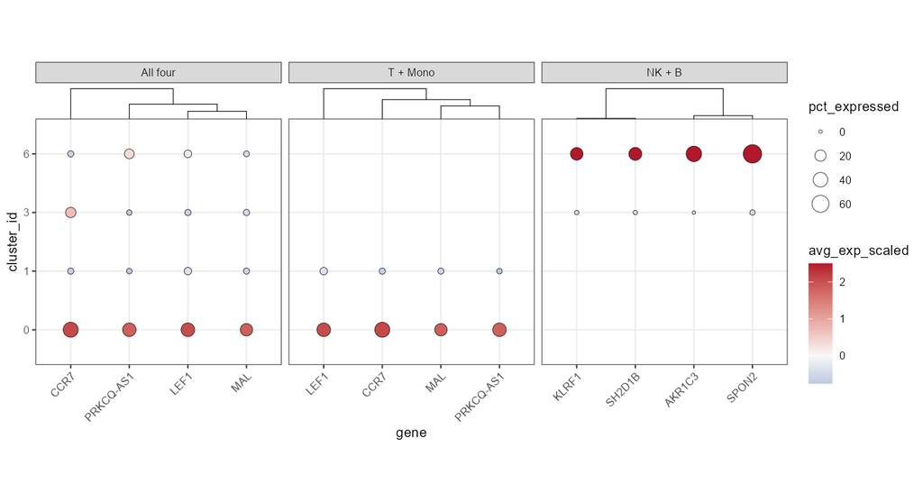

facet_gridn(scales = ‘free_x’): every panel gets its own x axis and its own x tree

```r
ggplot(d_xy, aes(gene, cluster_id)) + dot_layers() +
  facet_gridn(cols = vars(panel), scales = "free_x") +
  scale_x_cluster(position = "top", height = 0.9) +
  theme(aspect.ratio = 1)
```

Switch to `scales = "free"` and add `scale_y_cluster()` to get one x tree and one y tree **per cell**:

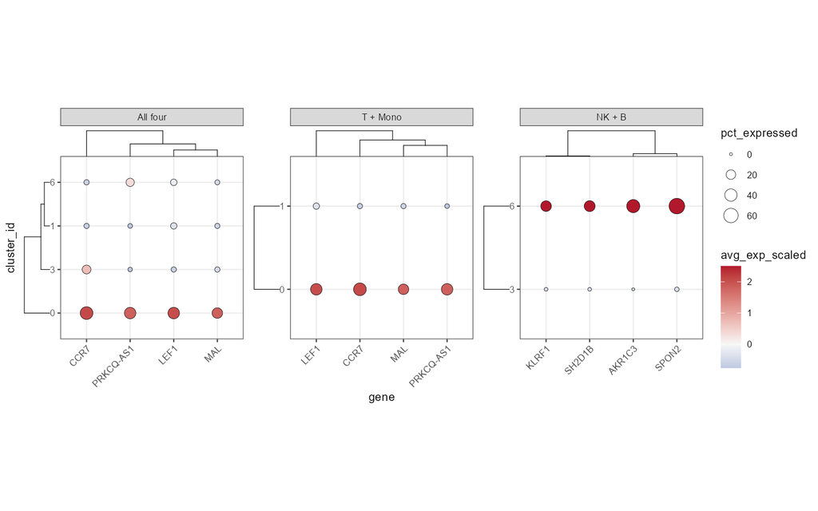

facet_gridn(scales = ‘free’): per-panel x and y trees

```r
ggplot(d_xy, aes(gene, cluster_id)) + dot_layers() +
  facet_gridn(cols = vars(panel), scales = "free") +
  scale_x_cluster(position = "top", height = 0.9) +
  scale_y_cluster(position = "left", height = 0.9) +
  theme(aspect.ratio = 1)
```

## Limits of the cluster tree

- **`position` only moves the tree.** To move the labels as well, use the usual `scale_x_discrete(position = "top")`; the two do not affect each other.
- **No tree when the facets map categories one to one.** A panel left with a single category (e.g. faceting by a cell type that is one-to-one with the cluster) has nothing to cluster and the tree is left blank.
- **Freeing both directions and drawing both trees flattens the panels**, because every y axis needs a column of its own. To see x and y at once, reduce `height` first, or keep a single direction.
- **An explicit matrix cannot be reordered per panel**: the tree falls back to a conservative “merge adjacent groups only” shape, which may look different from `hclust()`.
- **On a short canvas the panels collapse to zero height.** The tree row is a fixed height (`height` in cm), so with several panel rows on a small device (e.g. two rows in 4 inches) the fixed rows eat the `1null` panel rows and only the trees and axis text remain. Increase `fig.height` (leave 2-3 cm per panel row), use fewer panel rows, or lower `height`.

# Known limitations and tuning advice

- **It can only pick existing ticks, never add new ones.** If a category is not in the scale’s breaks, `which` cannot select it — add it first with `scale_x_discrete(breaks = ...)`.
- **Automatic rows are on demand.** One row whenever it fits (stretched along the axis, closest to the `anno_mark()` look); more rows only when the width overflows or the labels cluster, capped at `max_nrow` tracks. Write `nrow = 1` explicitly for the pure single-row `anno_mark` look.
- **Fewer labels than requested is possible.** On a narrow panel, or with too few rows, the guide drops labels by priority — it never draws overlapping labels. To show more, add `nrow`, make the figure larger, or reduce `padding`/`gap`.
- **Automatic thinning when `which = NULL` and `n = NULL`.** When the total width exceeds what `max_nrow` tracks can hold, the guide thins evenly and prints one `cli` message; `options(ggutils.quiet = TRUE)` silences it. Always prefer explicit `n =` or `which =`.
- **The automatic number of rows depends on the device.** The same plot may use a different number of rows in the RStudio window and in a 1600x900 PNG. For reproducible output write `nrow` explicitly, or tell the guide the panel width with `panel_width` (in cm).
- **`angle` is best combined with `nrow = 1`.** Rotated labels need more vertical space (the guide reserves the rotated bounding box), and stacking rotated labels is rarely worth it.
- **Never blank the labels with `axis.text.*`**: the guide inherits the blank element and draws no text; to hide labels, do not use the guide at all.
- **`coord_flip()` is superseded**: for new code map the discrete variable to the y axis. In old code attach the guide to the scale (`scale_x_discrete(guide = ...)`) or use `guides(y = ...)`; `guides(x = ...)` lands on the numeric axis after flipping.
- **`plot.margin` is only needed when `extend > 0`**: with the default `extend = 0` labels never leave the panel and are never clipped; if you increase `extend`, reserve the matching margin with `theme(plot.margin = ...)`.
- **Custom secondary axes**: `sec.axis = dup_axis(guide = guide_axis_smart(...))` is verified (see the “Local annotations and heatmap labels” section); check more involved secondary axes on a small plot first.
- Performance is not a concern: label measurement happens once at build time, and 200 categories are interactive-fast.

# Session info

```r
cat("ggplot2:", as.character(packageVersion("ggplot2")), "\n")
```

```
#> ggplot2: 4.0.3
```

```r
cat("ggutils:", as.character(packageVersion("ggutils")), "\n")
```

```
#> ggutils: 0.0.3
```

```r
cat("R:", R.version.string, "\n")
```

```
#> R: R version 4.5.1 (2025-06-13 ucrt)
```